# QALL401: Data Analysis for Researchers

## Course Contents

1. 2022.12.07: Introduction: About the course [lead by TK]
   - An introduction to open and public data, and data science
2. 2022-12-14: Exploratory Data Analysis (EDA) 1 [lead by hs]
   - R Basics with RStudio and/or RStudio.cloud; Toy Data
3. 2022-12-21: Exploratory Data Analysis (EDA) 2 [lead by hs]
   - R Markdown, `tidyverse` I: `dplyr`; `gapminder`
4. 2023-01-11: Exploratory Data Analysis (EDA) 3 [lead by hs]
   - `tidyverse`II: `readr`, `ggplot2`; Public Data, WDI, WIR, etc
5. 2023-01-18: Exploratory Data Analysis (EDA) 4 [lead by hs]
   - `tidyverse` III: `tidyr`, etc.; WDI, WIR, etc
6. 2023-01-25: Exploratory Data Analysis (EDA) 5 [lead by hs]
   - `tidyverse` IV; WDI, WIR, etc
7. 2023-02-01: Introduction to PPDAC
   - Problem-Plan-Data-Analysis-Conclusion Cycle: [lead by TK]
8. 2023-02-08: Model building I [lead by TK]
   - Collecting and visualizing data and Introduction to WDI  
     (World Development Indicators by World Bank)
9. 2023-02-15: Model building II [lead by TK]
   - Analyzing data and communications
10. 2023-02-22: Project Presentation

# 1 Exploratory Data Analysis (EDA) I

## 1.1 R with R Studio and/or R Studio.cloud

### 1.1.1 Learning Resources

#### 1.1.1.1 Textbooks and References

- “R for Data Science” by Hadley Wickham and Garrett Grolemund:
  - Free Online Book: https://r4ds.had.co.nz
- Visit `bookdown` site: https://bookdown.org
  - Many more on the [archive page](https://bookdown.org/home/archive/).

### 1.1.2 Interactive Exercises

- Posit Primers:https://posit.cloud/learn/primers:
  - The Basics, Work with Data, Visualize Data, Tidy Your Data, Report Reproducibly
- {swirl} Learn R, in R: https://swirlstats.com
  - Designed and developed by a team at Johns Hopkins University for `coursera` courses

### 1.1.3 Posit Primers created by `learnr`

- [`learnr` Interactive Tutorials for R](https://rstudio.github.io/learnr/index.html)

#### 1.1.3.1 Posit Primers https://posit.cloud/learn/primers

1. The Basics – [r4ds: Explore, I](https://r4ds.had.co.nz/explore-intro.html#explore-intro)
- [Visualization Basics](https://rstudio.cloud/learn/primers/1.1)
- [Programming Basics](https://rstudio.cloud/learn/primers/1.2)
2. Work with Data – [r4ds: Wrangle, I](https://r4ds.had.co.nz/wrangle-intro.html#wrangle-intro)
- Working with Tibbles
- Isolating Data with dplyr
- Deriving Information with dplyr
3. Visualize Data – [r4ds: Explore, II](https://r4ds.had.co.nz/explore-intro.html#explore-intro)
4. Tidy Your Data – [r4ds: Wrangle, II](https://r4ds.had.co.nz/wrangle-intro.html#wrangle-intro)
5. Iterate – [r4ds: Program](https://r4ds.had.co.nz/program-intro.html#program-intro)
6. Write Functions – [r4ds: Program](https://r4ds.had.co.nz/program-intro.html#program-intro)

### 1.1.4 Data Science and EDA

#### 1.1.4.1 Wikipedia https://en.wikipedia.org/wiki/Data_science

> An inter-disciplinary field that uses scientific methods, processes, algorithms and systems to extract knowledge and insights from many structural and unstructured data.
- Create Insights
- Impact Decision Making
- Maintain & Improve Overtime

### 1.1.5 What is R?

#### 1.1.5.1 R (programming language), Wikipedia

- **R is a programming language** and **free software** environment for **statistical computing and graphics** supported by the R Foundation for Statistical Computing.
- The R language is widely used among statisticians and data miners for developing statistical software and data analysis.
- A **GNU package**, the official R software environment is written primarily in C, Fortran, and R itself (thus, it is partially self-hosting) and is freely available under the GNU General Public License.

#### 1.1.5.2 History of R and more

“R Programming for Data Science” by Roger Peng

- [Chapter 2. History and Overview of R](https://bookdown.org/rdpeng/rprogdatascience/history-and-overview-of-r.html)
- [Overview and History of R: Youtube video](https://www.youtube.com/watch?v=STihTnVSZnI&feature=youtu.be)

### 1.1.6 Why R? – Responses by Hadley Wickham

#### 1.1.6.1 [r4ds](https://r4ds.had.co.nz/introduction.html#python-julia-and-friends): R is a great place to start your data science journey because

- R is an environment designed from the ground up to support data science.
- R is not just a programming language, but it is also an interactive environment for doing data science.
- To support interaction, R is a much more flexible language than many of its peers.

#### 1.1.6.2 Why R today?

When you talk about choosing programming languages, I always say you shouldn’t pick them based on technical merits, but rather pick them based on the community. And I think the R community is like really, really strong, vibrant, free, welcoming, and embraces a wide range of domains. So, if there are like people like you using R, then your life is going to be much easier. That’s the first reason.

**Interview**: [“Advice to Young (and Old) Programmers, H. Wickham”](https://www.r-bloggers.com/2018/08/advice-to-young-and-old-programmers-a-conversation-with-hadley-wickham/)

### 1.1.7 What is RStudio? https://posit.com

> RStudio is an integrated development environment, or IDE, for R programming.

#### 1.1.7.1 R Studio (Wikipedia)

RStudio is an integrated development environment (IDE) for R, a programming language for statistical computing and graphics. It is available in two formats: RStudio Desktop is a regular desktop application while RStudio Server runs on a remote server and allows accessing RStudio using a web browser.

### 1.1.8 Installation of R and R Studio

#### 1.1.8.1 R Installation

To download R, go to CRAN, the comprehensive R archive network. CRAN is composed of a set of mirror servers distributed around the world and is used to distribute R and R packages. Don’t try and pick a mirror that’s close to you: instead use the cloud mirror, https://cloud.r-project.org, which automatically figures it out for you.

A new major version of R comes out once a year, and there are 2-3 minor releases each year. It’s a good idea to update regularly.

#### 1.1.8.2 R Studio Installation

Download and install it from http://www.rstudio.com/download.

RStudio is updated a couple of times a year. When a new version is available, RStudio will let you know.

### 1.1.9 R Studio

#### 1.1.9.1 The First Step

1. Start R Studio Application
2. Top Menu: File > New Project > New Directory > New Project > *Directory name or Browse the directory and choose the parent directory you want to create the directory*

#### 1.1.9.2 When You Start the Project

1. Go to the directory you created
2. Double click _‘Directory Name’.Rproj

Or,

1. Start R Studio
2. File > Open Project (or choose from Recent Project)

*In this way the working directory of the session is set to the project directory and R can search releted files without difficulty* (`getwd()`, `setwd()`)

### 1.1.10 Posit Cloud

RStudio Cloud is a lightweight, cloud-based solution that allows anyone to do, share, teach and learn data science online.

#### 1.1.10.1 Cloud Free

- Up to 15 projects total
- 1 shared space (5 members and 10 projects max)
- 15 project hours per month
- Up to 1 GB RAM per project
- Up to 1 CPU per project
- Up to 1 hour background execution time

#### 1.1.10.2 How to Start Posit Cloud

1. Go to https://posit.cloud/
2. Sign Up: *top right*
- Email address or Google account
3. New Project: *Project Name*
4. R Console

## 1.2 Let’s Get Started

Start RStudio and create a project, or login to Posit Cloud and create a project.

### 1.2.1 The First Examples

Input the following codes into Console in the left bottom pane.

- The first two:

```r
head(cars)
```

|  | speed | dist |
| --- | --- | --- |
| 1 | 4 | 2 |
| 2 | 4 | 10 |
| 3 | 7 | 4 |
| 4 | 7 | 22 |
| 5 | 8 | 16 |
| 6 | 9 | 10 |

```r
str(cars)
```

```
'data.frame':   50 obs. of  2 variables:
 $ speed: num  4 4 7 7 8 9 10 10 10 11 ...
 $ dist : num  2 10 4 22 16 10 18 26 34 17 ...
```

```r
plot(cars) # cars: Speed and Stopping Distances of Cars
abline(lm(cars$dist~cars$speed))
```

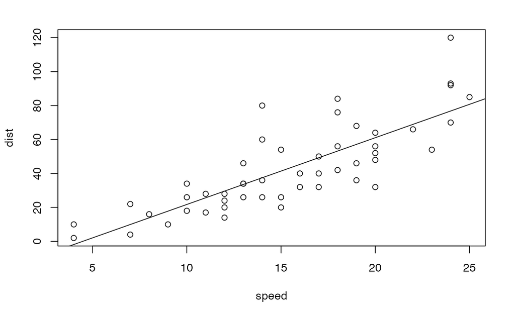

```r
lm(cars$dist~cars$speed)
```

```
Call:
lm(formula = cars$dist ~ cars$speed)

Coefficients:
(Intercept)   cars$speed
    -17.579        3.932
```

```r
summary(lm(cars$dist~cars$speed))
```

```
Call:
lm(formula = cars$dist ~ cars$speed)

Residuals:
    Min      1Q  Median      3Q     Max
-29.069  -9.525  -2.272   9.215  43.201

Coefficients:
            Estimate Std. Error t value Pr(>|t|)
(Intercept) -17.5791     6.7584  -2.601   0.0123 *
cars$speed    3.9324     0.4155   9.464 1.49e-12 ***
---
Signif. codes:  0 ‘***’ 0.001 ‘**’ 0.01 ‘*’ 0.05 ‘.’ 0.1 ‘ ’ 1

Residual standard error: 15.38 on 48 degrees of freedom
Multiple R-squared:  0.6511,    Adjusted R-squared:  0.6438
F-statistic: 89.57 on 1 and 48 DF,  p-value: 1.49e-12
```

#### 1.2.1.1 Brief Explanation

- `head(cars)`: The first 6 rows of the pre-installed data `cars`.
- `str(cars)`: The data structure of the pre-installed data `cars`.
- `summary(cars)`: The summary of the pre-installed data `cars`.
- `plot(cars)`: A scatter plot of the pre-installed data `cars`.
  - `plot(cars$dist~cars$speed)`
  - `cars$dist`, `cars$[[2]]`, `cars[,2]` are same
- `abline(lm(cars$dist~cars$speed))`: Add a regression line of a linear model
- `lm(cars$dist~cars$speed)`: The equation of the regression line
- `summary(lm(cars$dist~cars$speed)`: The summary of the linear regression model

```r
hist(cars$dist)
```

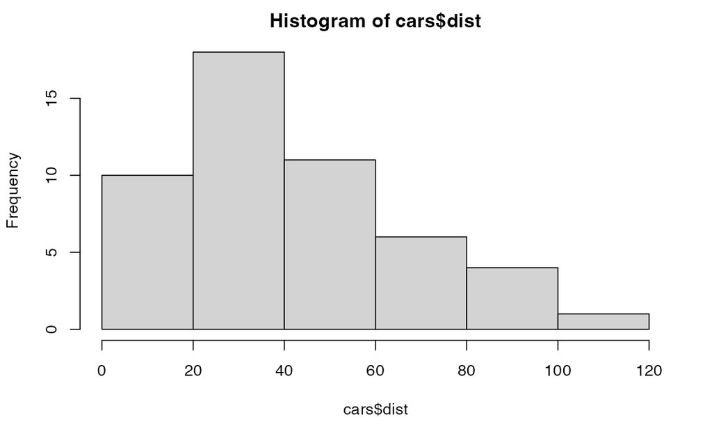

```r
hist(cars$speed)
```

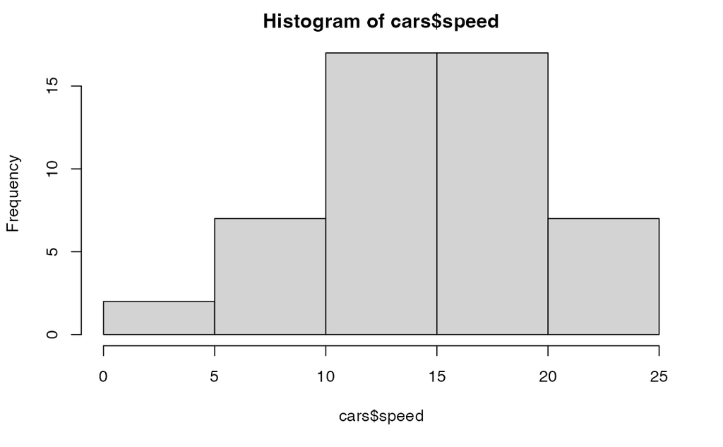

#### 1.2.1.2 View and help

- `View(cars)`
- `?cars`: same as `help(cars)`
- `??cars`: same as `help.search(“cars”)

#### 1.2.1.3 `datasets`

- `?datasets`
- `library(help = "datasets")`
- `data()` shows all data already attached and available.

### 1.2.2 Practicum

Pick a data in the datasets package and try

- `head()`
- `str()`
- `summary()`

and some more.

#### 1.2.2.1 `iris`

```r
head(iris)
```

|  | Sepal.Length | Sepal.Width | Petal.Length | Petal.Width | Species |
| --- | --- | --- | --- | --- | --- |
| 1 | 5.1 | 3.5 | 1.4 | 0.2 | setosa |
| 2 | 4.9 | 3.0 | 1.4 | 0.2 | setosa |
| 3 | 4.7 | 3.2 | 1.3 | 0.2 | setosa |
| 4 | 4.6 | 3.1 | 1.5 | 0.2 | setosa |
| 5 | 5.0 | 3.6 | 1.4 | 0.2 | setosa |
| 6 | 5.4 | 3.9 | 1.7 | 0.4 | setosa |

```r
str(iris)
```

```
'data.frame':   150 obs. of  5 variables:
 $ Sepal.Length: num  5.1 4.9 4.7 4.6 5 5.4 4.6 5 4.4 4.9 ...
 $ Sepal.Width : num  3.5 3 3.2 3.1 3.6 3.9 3.4 3.4 2.9 3.1 ...
 $ Petal.Length: num  1.4 1.4 1.3 1.5 1.4 1.7 1.4 1.5 1.4 1.5 ...
 $ Petal.Width : num  0.2 0.2 0.2 0.2 0.2 0.4 0.3 0.2 0.2 0.1 ...
 $ Species     : Factor w/ 3 levels "setosa","versicolor",..: 1 1 1 1 1 1 1 1 1 1 ...
```

```r
summary(iris)
```

```
  Sepal.Length    Sepal.Width     Petal.Length    Petal.Width          Species
 Min.   :4.300   Min.   :2.000   Min.   :1.000   Min.   :0.100   setosa    :50
 1st Qu.:5.100   1st Qu.:2.800   1st Qu.:1.600   1st Qu.:0.300   versicolor:50
 Median :5.800   Median :3.000   Median :4.350   Median :1.300   virginica :50
 Mean   :5.843   Mean   :3.057   Mean   :3.758   Mean   :1.199
 3rd Qu.:6.400   3rd Qu.:3.300   3rd Qu.:5.100   3rd Qu.:1.800
 Max.   :7.900   Max.   :4.400   Max.   :6.900   Max.   :2.500
```

Can you plot?

```r
plot(iris$Sepal.Length, iris$Sepal.Width)
```

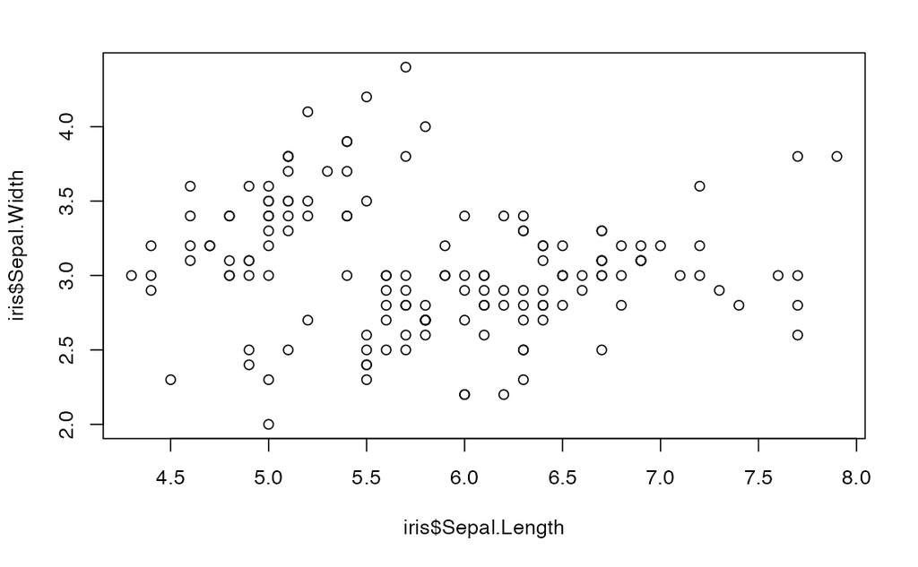

## 1.3 `tidyverse` Packages

### 1.3.1 Brief Introduction to R on RStudio

#### 1.3.1.1 Four Panes and Tabs

1. Top Left: Source Editor
2. Top Right: Environment, History, etc.
3. Bottom Left: Console, Terminal, Render, Background Jobs
4. Bottom Right: Files, Plots, Packages, Help, Viewer, Presentation

#### 1.3.1.2 Set up

- Highly recommend to set the language to be “English”.
- Create “data” directory.

```r
Sys.setenv(LANG = "en")
dir.create("data")
```

#### 1.3.1.3 Three Ways to Run Codes

1. Console - Bottom Left Pane
2. R Script - pull down menu under File
3. R Notebook, R Markdown - pull down menu under File

### 1.3.2 Second Way: R Script

#### 1.3.2.1 Examples: R Scripts in Moodle

- `basics.R`
- `coronavirus.R`
1. Copy a script in Moodle: *{file name}.R*
2. In RStudio (create Project in RStudio) choose File > New File > R Script and paste it.
3. Choose File > Save with a name; e.g. *{file names}* (.R will be added automatically)

### 1.3.3 Packages

R packages are extensions to the R statistical programming language. R packages contain code, data, and documentation in a standardised collection format that can be installed by users of R, typically via a centralised software repository such as CRAN (the Comprehensive R Archive Network).

#### 1.3.3.1 Installation and attachement

You can install packages by “Install Packages…” under “Tool” in the top menu.

- `install.packages("tidyverse")`
- `install.packages("rmarkdown")`

### 1.3.4 Third Way: R Notebook

Choose R Notebook from the pull down File menu in the top bar.

### 1.3.5 Edit YAML

**Default* is as follows**

```
---
title: "R Notebook"
output: html_notebook
---
```

**Template**

```
---
title: "Title of R Notebook"
author: "ID and Your Name"
date: "2023-01-14"
output:
  html_notebook:
#    number_sections: yes
#    toc: true
#    toc_float: true
---
```

- Don’t change the format. Indention matters.
- The statement after # is ignored.
- Date is automatically inserted when you compile the file.
- You can replace “2023-01-14” by “2022-12-14” or in any date format surrounded by double quotation marks.
- Section numbers: - default is `number_sections: no`.
- Table of contents, `toc: true` - default is `toc: false`.
- Floating table of contents in HTML output, `toc_float: true` - default is `toc_float: false`

### 1.3.6 Create a Code Chunk to Attach Packages

Insert Chunk in Code pull down menu in the top bar, or use the `C` button on top. You can use shortcut keys listed under Tools in the top bar.

```r
library(tidyverse)
```

## 1.4 First Example

### 1.4.1 Importing data

Let us assign the `iris` data in the pre-installed package `datasets` to `df_iris`. You can give any name starting from an alphabet, though there are some rules.

```r
df_iris <- datasets::iris
class(df_iris)
```

```
[1] "data.frame"
```

The class of data `iris` is `data.frame`, the basic data class of R. You can assign the same data as a `tibble`, the data class of `tidyverse` as follows.

```r
tbl_iris <- as_tibble(datasets::iris)
class(tbl_iris)
```

```
[1] "tbl_df"     "tbl"        "data.frame"
```

- `df_iris <- iris` can replace `df_iris <- datasets::iris` because the package `datasets` is installed and attached as default. Since you may have other data called `iris` included in a different package or you may have changed `iris` before, it is safer to specify the name of the package with the name of the data.
- Within R Notebook or in Console, you may get different output, and `tf_iris` and `tbl_iris` behave differently. It is because of the default settings of R Markdown.

### 1.4.2 Look at the data

#### 1.4.2.1 Several ways to view the data.

The `View` command open up a window to show the contents of the data and you can use the filter as well.

```r
View(df_iris)
```

The following simple command also shows the data.

```r
df_iris
```

| Sepal.Length | Sepal.Width | Petal.Length | Petal.Width | Species |
| --- | --- | --- | --- | --- |
| 5.1 | 3.5 | 1.4 | 0.2 | setosa |
| 4.9 | 3.0 | 1.4 | 0.2 | setosa |
| 4.7 | 3.2 | 1.3 | 0.2 | setosa |
| 4.6 | 3.1 | 1.5 | 0.2 | setosa |
| 5.0 | 3.6 | 1.4 | 0.2 | setosa |
| 5.4 | 3.9 | 1.7 | 0.4 | setosa |
| 4.6 | 3.4 | 1.4 | 0.3 | setosa |
| 5.0 | 3.4 | 1.5 | 0.2 | setosa |
| 4.4 | 2.9 | 1.4 | 0.2 | setosa |
| 4.9 | 3.1 | 1.5 | 0.1 | setosa |

[output cut: 140 more lines]

The output within R Notebook is a tibble style. Try the same command in Console.

```r
slice(df_iris, 1:10)
```

| Sepal.Length | Sepal.Width | Petal.Length | Petal.Width | Species |
| --- | --- | --- | --- | --- |
| 5.1 | 3.5 | 1.4 | 0.2 | setosa |
| 4.9 | 3.0 | 1.4 | 0.2 | setosa |
| 4.7 | 3.2 | 1.3 | 0.2 | setosa |
| 4.6 | 3.1 | 1.5 | 0.2 | setosa |
| 5.0 | 3.6 | 1.4 | 0.2 | setosa |
| 5.4 | 3.9 | 1.7 | 0.4 | setosa |
| 4.6 | 3.4 | 1.4 | 0.3 | setosa |
| 5.0 | 3.4 | 1.5 | 0.2 | setosa |
| 4.4 | 2.9 | 1.4 | 0.2 | setosa |
| 4.9 | 3.1 | 1.5 | 0.1 | setosa |

```r
1:10
```

```
 [1]  1  2  3  4  5  6  7  8  9 10
```

#### 1.5.0.1 Data Structure

Let us look at the structure of the data. You can try `str(df_iris)` on Console or by adding a code chunk in R Notebook introducing later.

```r
glimpse(df_iris)
```

```
Rows: 150
Columns: 5
$ Sepal.Length <dbl> 5.1, 4.9, 4.7, 4.6, 5.0, 5.4, 4.6, 5.0, 4.4, 4.9, 5.4, 4.8, 4.8, 4.3, 5.8, …
$ Sepal.Width  <dbl> 3.5, 3.0, 3.2, 3.1, 3.6, 3.9, 3.4, 3.4, 2.9, 3.1, 3.7, 3.4, 3.0, 3.0, 4.0, …
$ Petal.Length <dbl> 1.4, 1.4, 1.3, 1.5, 1.4, 1.7, 1.4, 1.5, 1.4, 1.5, 1.5, 1.6, 1.4, 1.1, 1.2, …
$ Petal.Width  <dbl> 0.2, 0.2, 0.2, 0.2, 0.2, 0.4, 0.3, 0.2, 0.2, 0.1, 0.2, 0.2, 0.1, 0.1, 0.2, …
$ Species      <fct> setosa, setosa, setosa, setosa, setosa, setosa, setosa, setosa, setosa, set…
```

There are six types of data in R; Double, Integer, Character, Logical, Raw, Complex.

The names after $ are column names. If you call `df_iris$Species`, you have the Species column. Species is in the 5th collumn, `typeof(df_iris[[5]])` does the same as the next.

```r
typeof(df_iris$Species)
```

```
[1] "integer"
```

```r
class(df_iris$Species)
```

```
[1] "factor"
```

For `factors = fct` see [the R Document](https://www.rdocumentation.org/packages/base/versions/3.6.2/topics/factor) or an explanation in [Factor in R: Categorical Variable & Continuous Variables](https://www.guru99.com/r-factor-categorical-continuous.html).

```r
typeof(df_iris$Sepal.Length)
```

```
[1] "double"
```

```r
class(df_iris$Sepal.Length)
```

```
[1] "numeric"
```

**Q1.** What are the differences of`df_iris`, `slice(df_iris, 1:10)` and `glimpse(df_iris)` above?

**Q2.** What are the differences of`df_iris`, `slice(df_iris, 1:10)` and `glimpse(df_iris)` in the console?

#### 1.5.0.2 Summary of the Data

The following is very convenient to get the summary information of a data.

```r
summary(df_iris)
```

```
  Sepal.Length    Sepal.Width     Petal.Length    Petal.Width          Species
 Min.   :4.300   Min.   :2.000   Min.   :1.000   Min.   :0.100   setosa    :50
 1st Qu.:5.100   1st Qu.:2.800   1st Qu.:1.600   1st Qu.:0.300   versicolor:50
 Median :5.800   Median :3.000   Median :4.350   Median :1.300   virginica :50
 Mean   :5.843   Mean   :3.057   Mean   :3.758   Mean   :1.199
 3rd Qu.:6.400   3rd Qu.:3.300   3rd Qu.:5.100   3rd Qu.:1.800
 Max.   :7.900   Max.   :4.400   Max.   :6.900   Max.   :2.500
```

Minimum, 1st Quadrant (25%), Median, Mean, 3rd Quadrant (75%), Maximum, and the count of each factor.

### 1.5.1 Visualizing Data

#### 1.5.1.1 Scatter Plot

We use `ggplot` to draw graphs. The scatter plot is a projection of data with two variables $x$ and $y$.

```
ggplot(data = <data>, aes(x = <column name for x>, y = <column name for y>)) +
  geom_point()
```

```
ggplot(data = df_iris, aes(x = Sepal.Length, y = Sepal.Width)) +
  geom_point()
```

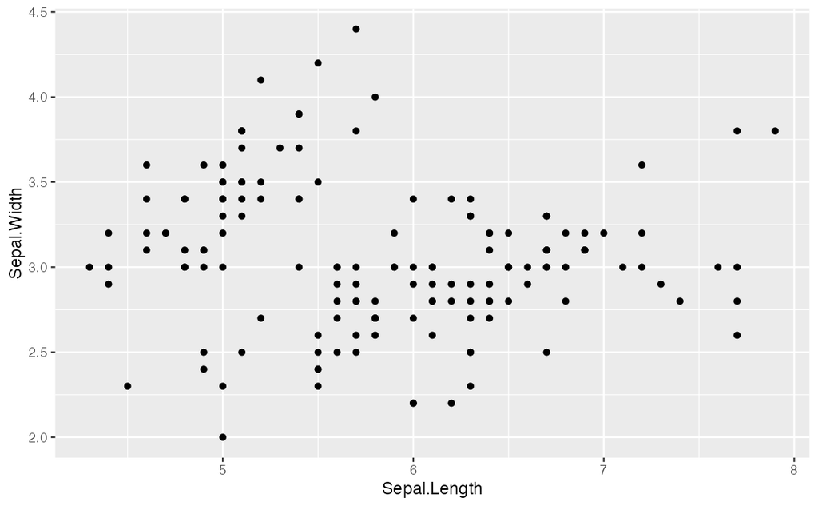

```r
ggplot(data = df_iris, aes(x = Sepal.Length, y = Sepal.Width)) +
  geom_point()
```

#### 1.5.1.2 Scatter Plot with [Labels](https://ggplot2.tidyverse.org/reference/labs.html)

Add title and labels adding `labs()`.

```
ggplot(data = <data>, aes(x = <column name for x>, y = <column name for y>)) +
  geom_point() +
  labs(title = "Title", x = "Label for x", y = "Label for y")
```

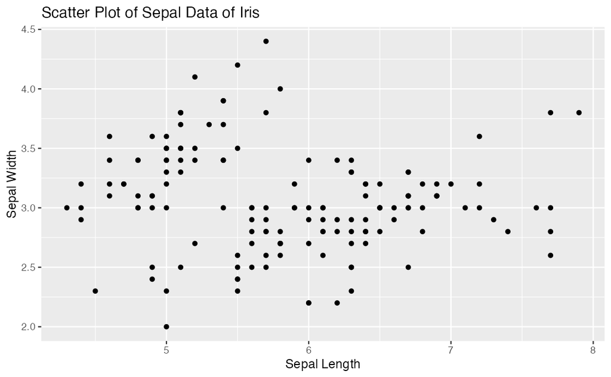

```r
ggplot(data = df_iris, aes(x = Sepal.Length, y = Sepal.Width)) +
  geom_point() +
  labs(title = "Scatter Plot of Sepal Data of Iris", x = "Sepal Length", y = "Sepal Width")
```

#### 1.5.1.3 Scatter Plot with [Colors](https://ggplot2.tidyverse.org/reference/aes_colour_fill_alpha.html)

Add different colors automatically to each species. Can you see each group?

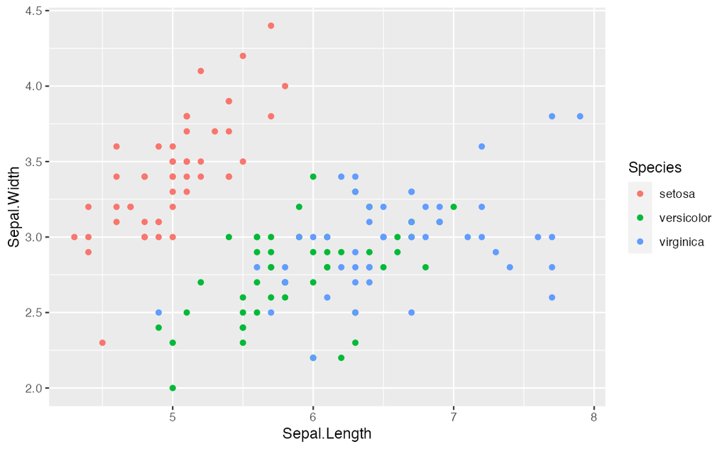

```r
ggplot(data = df_iris, aes(x = Sepal.Length, y = Sepal.Width, color = Species)) +
  geom_point()
```

#### 1.5.1.4 Scatter Plot with Shapes

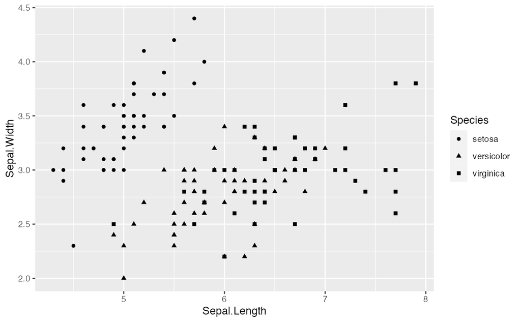

```r
ggplot(data = df_iris, aes(x = Sepal.Length, y = Sepal.Width, shape = Species)) +
  geom_point()
```

#### 1.5.1.5 [Boxplot](https://ggplot2.tidyverse.org/reference/geom_boxplot.html)

The boxplot compactly displays the distribution of a continuous variable.

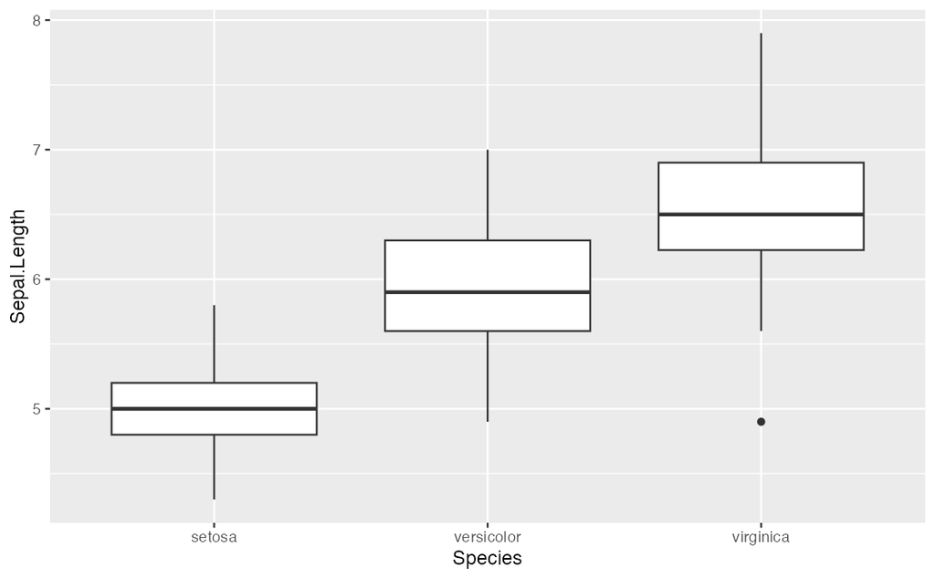

```r
ggplot(data = df_iris, aes(x = Species, y = Sepal.Length)) +
  geom_boxplot()
```

#### 1.5.1.6 [Histogram](https://ggplot2.tidyverse.org/reference/geom_histogram.html)

Visualize the distribution of a single continuous variable by dividing the x axis into bins and counting the number of observations in each bin. Histograms (geom_histogram()) display the counts with bars.

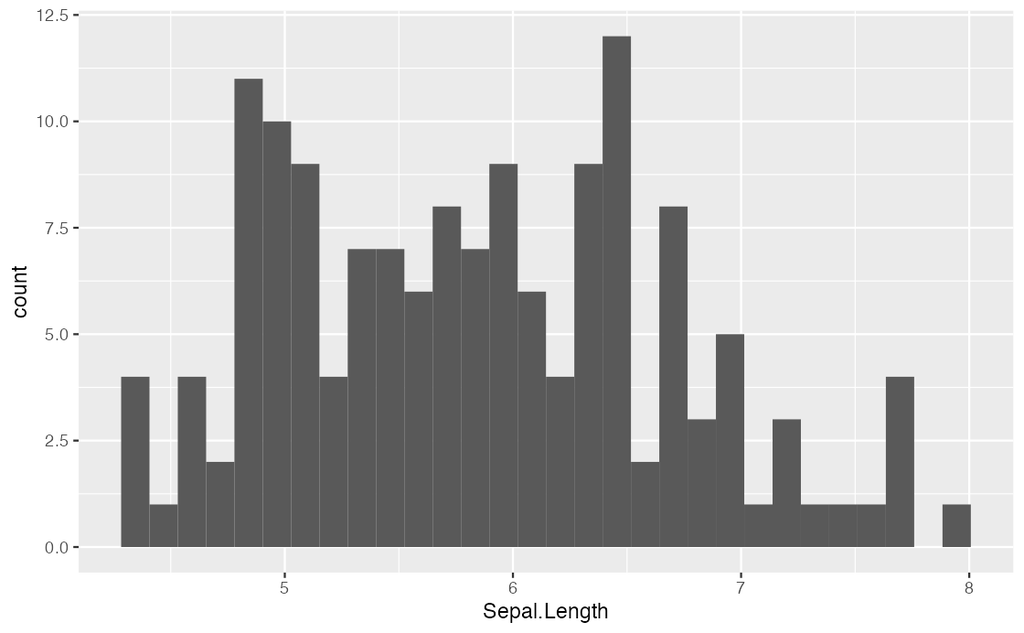

```r
ggplot(data = df_iris, aes(x = Sepal.Length)) +
  geom_histogram()
```

Change the number of bins by `bins =` `<number>`.

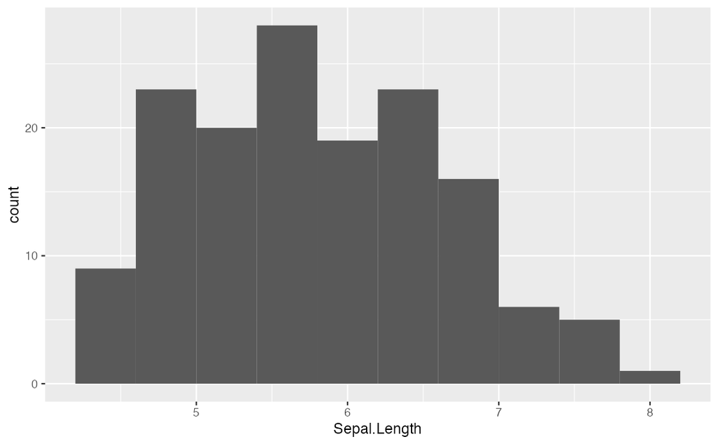

```r
ggplot(data = df_iris, aes(x = Sepal.Length)) +
  geom_histogram(bins = 10)
```

### 1.5.2 Data Modeling

Professor Kaizoji will cover the mathematical models and hypothesis testings.

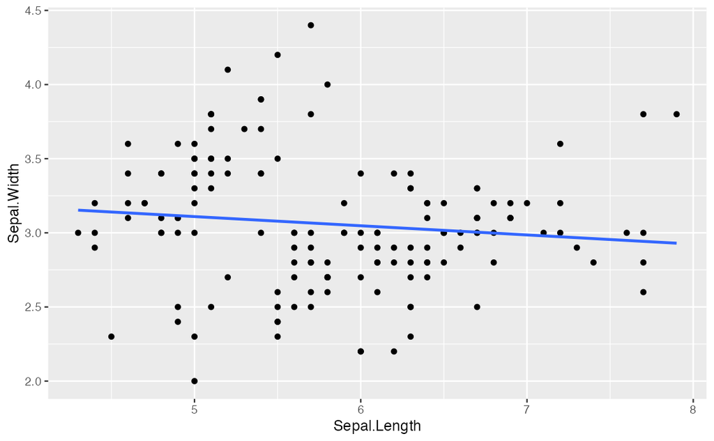

```r
ggplot(data = df_iris, aes(x = Sepal.Length, y = Sepal.Width)) +
  geom_point() +
  geom_smooth(method = "lm", se = FALSE)
```

## 1.6 Comments on Week 2

#### 1.6.0.1 Helpful Resources

- Cheat Sheet in RStudio: https://www.rstudio.com/resources/cheatsheets/
  - [RStudio IED](https://raw.githubusercontent.com/rstudio/cheatsheets/main/rstudio-ide.pdf)
  - [Base R Cheat Sheet](https://github.com/rstudio/cheatsheets/raw/main/base-r.pdf)
- ‘Quick R’ by DataCamp: https://www.statmethods.net/management
- [An Introduction to R](https://cran.rstudio.com)

#### 1.6.0.2 Practicum

- Posit Primers: The Basics: https://posit.cloud/learn/primers/1
  - Complete Visualization Basics and Programming Basics

#### 1.6.0.3 Assignments - See Moodle

1. Assignment Week 2-1: Introduction Plus Forum
- Due: Tuesday, 20 December 2022, 11:59 PM
2. Assignment Week 2-2: Quiz 1 on R Basics
- Due: Tuesday, 20 December 2022, 11:59 PM

## 1.7 Swirl: An interactive learning environment for R and statistics

- {`swirl`} website: https://swirlstats.com
- JHU Data Science in coursera uses `swirl` for exercises.

### 1.7.1 Swirl Courses

1. R Programming: The basics of programming in R
2. Regression Models: The basics of regression modeling in R
3. Statistical Inference: The basics of statistical inference in R
4. Exploratory Data Analysis: The basics of exploring data in R

You can install other `swirl` courses as well

- [Swirl Courses Organized by Title](http://swirlstats.com/scn/title.html)
- [Swirl Courses Organized by Author’s Name](http://swirlstats.com/scn/surname.html)
- [Github: swirl courses](https://github.com/swirldev/swirl_courses#swirl-courses)
  - `install_course("Course Name Here")`

### 1.7.2 Install and Start Swirl Courses

#### 1.7.2.1 Three Steps to Start Swirl

```
install.packages("swirl") # Only the first time.
library(swirl) # Everytime you start swirl
swirl() # Everytime you start or resume swirl
```

#### 1.7.2.2 R Programming: The basics of programming in R

```
 1: Basic Building Blocks      2: Workspace and Files     3: Sequences of Numbers
 4: Vectors                    5: Missing Values          6: Subsetting Vectors
 7: Matrices and Data Frames   8: Logic                   9: Functions
10: lapply and sapply         11: vapply and tapply      12: Looking at Data
13: Simulation                14: Dates and Times        15: Base Graphics
```

#### 1.7.2.3 Recommended Sections in Order

1, 3, 4, 5, 6, 7, 12, 15, 14, 8, 9, 10, 11, 13, 2

- Section 2 discusses the directories and file systems of a computer
- Sections 9, 10, 11 are for programming

#### 1.7.2.4 Controling a `swirl` Session

- … <– That’s your cue to press Enter to continue
- You can exit swirl and return to the R prompt (>) at any time by pressing the Esc key.
- If you are already at the prompt, type bye() to exit and save your progress. When you exit properly, you’ll see a short message letting you know you’ve done so.

When you are at the R prompt (>):

1. Typing skip() allows you to skip the current question.
2. Typing play() lets you experiment with R on your own; swirl will ignore what you do…
3. UNTIL you type nxt() which will regain swirl’s attention.
4. Typing bye() causes swirl to exit. Your progress will be saved.
5. Typing main() returns you to swirl’s main menu.
6. Typing info() displays these options again.

#### 1.7.2.5 Final Remark

You will encounter the message like ‘Would you like to receive credit for completing this course on Coursera.org?’ at the end of each course. This is for `coursera` courses. Select ‘NO’.

## 1.8 More on R Script: Examples

### 1.8.1 R Scripts in Moodle

- basics.R
- coronavirus.R
1. Copy a script in Moodle: *{file name}.R*
2. In RStudio (Workspace in RStudio.cloud, Project in RStudio) choose File > New File > R Script and paste it.
3. Choose File > Save with a name; e.g. *{file names}* (.R will be added automatically)

### 1.8.2 `basics.R`

```r
#################
#
# basics.R
#
################
# 'Quick R' by DataCamp may be a handy reference:
#     https://www.statmethods.net/management/index.html
# Cheat Sheet at RStudio: https://www.rstudio.com/resources/cheatsheets/
# Base R Cheat Sheet: https://github.com/rstudio/cheatsheets/raw/main/base-r.pdf
# To execute the line: Control + Enter (Window and Linux), Command + Enter (Mac)
## try your experiments on the console

## calculator

3 + 7

### +, -, *, /, ^ (or **), %%, %/%

3 + 10 / 2

3^2

2^3

2*2*2

### assignment: <-, (=, ->, assign())

x <- 5

x

#### object_name <- value, '<-' shortcut: Alt (option) + '-' (hyphen or minus)
#### Object names must start with a letter and can only contain letter, numbers, _ and .

this_is_a_long_name <- 5^3

this_is_a_long_name

char_name <- "What is your name?"

char_name

#### Use 'tab completion' and 'up arrow'

### ls(): list of all assignments

ls()
ls.str()

#### check Environment in the upper right pane

### (atomic) vectors

5:10

a <- seq(5,10)

a

b <- 5:10

identical(a,b)

seq(5,10,2) # same as seq(from = 5, to = 10, by = 2)

c1 <- seq(0,100, by = 10)

c2 <- seq(0,100, length.out = 10)

c1

c2

length(c1)

#### ? seq   ? length   ? identical

(die <- 1:6)

zero_one <- c(0,1) # same as 0:1

die + zero_one # c(1,2,3,4,5,6) + c(0,1). re-use

d1 <- rep(1:3,2) # repeat


d1

die == d1

d2 <- as.character(die == d1)

d2

d3 <- as.numeric(die == d1)

d3

### class() for class and typeof() for mode
### class of vectors: numeric, charcters, logical
### types of vectors: doubles, integers, characters, logicals (complex and raw)

typeof(d1); class(d1)

typeof(d2); class(d2)

typeof(d3); class(d3)

sqrt(2)

sqrt(2)^2

sqrt(2)^2 - 2

typeof(sqrt(2))

typeof(2)

typeof(2L)

5 == c(5)

length(5)

### Subsetting

(A_Z <- LETTERS)

A_F <- A_Z[1:6]

A_F

A_F[3]

A_F[c(3,5)]

large <- die > 3

large

even <- die %in% c(2,4,6)

even

A_F[large]

A_F[even]

A_F[die < 4]

### Compare df with df1 <- data.frame(number = die, alphabet = A_F)
df <- data.frame(number = die, alphabet = A_F, stringsAsFactors = FALSE)

df

df$number

df$alphabet

df[3,2]

df[4,1]

df[1]

class(df[1])

class(df[[1]])

identical(df[[1]], die)

identical(df[1],die)

####################
# The First Example
####################

plot(cars)

# Help

? cars

# cars is in the 'datasets' package

data()

# help(cars) does the same as ? cars
# You can use Help tab in the right bottom pane

help(plot)
? par

head(cars)

str(cars)

summary(cars)

x <- cars$speed
y <- cars$dist

min(x)
mean(x)
quantile(x)

plot(cars)

abline(lm(cars$dist ~ cars$speed))

summary(lm(cars$dist ~ cars$speed))

boxplot(cars)

hist(cars$speed)
hist(cars$dist)
hist(cars$dist, breaks = seq(0,120, 10))
```

### 1.8.3 coronavirus.R

```r
# https://coronavirus.jhu.edu/map.html
# JHU Covid-19 global time series data
# See R pakage coronavirus at: https://github.com/RamiKrispin/coronavirus
# Data taken from: https://github.com/RamiKrispin/coronavirus/tree/master/csv
# Last Updated
Sys.Date()

## Download and read csv (comma separated value) file
coronavirus <- read.csv("https://github.com/RamiKrispin/coronavirus/raw/master/csv/coronavirus.csv")
# write.csv(coronavirus, "data/coronavirus.csv")

## Summaries and structures of the data
head(coronavirus)
str(coronavirus)
coronavirus$date <- as.Date(coronavirus$date)
str(coronavirus)

range(coronavirus$date)
unique(coronavirus$country)
unique(coronavirus$type)

## Set Country
COUNTRY <- "Japan"
df0 <- coronavirus[coronavirus$country == COUNTRY,]
head(df0)
tail(df0)
(pop <- df0$population[1])
df <- df0[c(1,6,7,13)]
str(df)
head(df)
### alternatively,
head(df0[c("date", "type", "cases", "population")])
###

## Set types
df_confirmed <- df[df$type == "confirmed",]
df_death <- df[df$type == "death",]
df_recovery <- df[df$data_type == "recovery",]
head(df_confirmed)
head(df_death)
head(df_recovery)

## Histogram
plot(df_confirmed$date, df_confirmed$cases, type = "h")
plot(df_death$date, df_death$cases, type = "h")
# plot(df_recovered$date, df_recovered$cases, type = "h") # no data for recovery

## Scatter plot and correlation
plot(df_confirmed$cases, df_death$cases, type = "p")
cor(df_confirmed$cases, df_death$cases)


## In addition set a period
start_date <- as.Date("2021-07-01")
end_date <- Sys.Date()
df_date <- df[df$date >=start_date & df$date <= end_date,]
##

## Set types
df_date_confirmed <- df_date[df_date$type == "confirmed",]
df_date_death <- df_date[df_date$type == "death",]
df_date_recovery <- df_date[df_date$data_type == "recovery",]
head(df_date_confirmed)
head(df_date_death)
head(df_date_recovery)

## Histogram
plot(df_date_confirmed$date, df_date_confirmed$cases, type = "h")
plot(df_date_death$date, df_date_death$cases, type = "h")
# plot(df_date_recovered$date, df_date_recovered$cases, type = "h") # no data for recovery

plot(df_date_confirmed$cases, df_date_death$cases, type = "p")
cor(df_date_confirmed$cases, df_date_death$cases)

### Q0. Change the values of the location and the period and see the outcomes.
### Q1. What is the correlation between df_confirmed$cases and df_death$cases?
### Q2. Do we have a larger correlation value if we shift the dates to implement the time-lag?
### Q3. Do you have any other questions to explore?

#### Extra
plot(df_confirmed$date, df_confirmed$cases, type = "h",
     main = paste("Comfirmed Cases in",COUNTRY),
     xlab = "Date", ylab = "Number of Cases")
```

## 1.9 `gapminder` Package

### 1.9.1 Hans Rosling (1948 – 2017)

> Hans Rosling was a Swedish physician, academic, and public speaker. He was a professor of international health at Karolinska Institute[4] and was the co-founder and chairman of the Gapminder Foundation, which developed the Trendalyzer software system. ([wikipedia](https://en.wikipedia.org/wiki/Hans_Rosling))
- Books:
  - Factfulness: Ten Reasons We’re Wrong About The World - And Why Things Are Better Than You Think, 2018
  - How I Learned to Understand the World: A Memoir, 2020
- Gapminder: https://www.gapminder.org
  - [You are probably wrong about: Upgrade Your World View](https://upgrader.gapminder.org)
  - [Bubble Chart](https://www.gapminder.org/tools/#$state$time$value=2020;;&chart-type=bubbles): Income vs Life Expectancy over time, 1800 - 2020
    - How many variables?
- Videos: [The best stats you’ve ever seen, Hans Rosling](http://www.edtech.events/the-best-stats-youve-ever-seen-hans-rosling/)

### 1.9.2 Factfulness is … *From the book*

recognizing when a decision feels urgent and remembering that it rarely is.

To control the urgency instinct, take small steps.

- Take a breath. When your urgency instinct is triggered, your other instincts kick in and your analysis shuts down. Ask for more time and more information. It’s rarely now or never and it’s rarely either/or.
- Insist on the data. If something is urgent and important, it should be measured. Beware of data that is relevant but inaccurate, or accurate but irrelevant. Only relevant and accurate data is useful.
- Beware of fortune-tellers. Any prediction about the future is uncertain. Be wary of predictions that fail to acknowledge that. Insist on a full range of scenarios, never just the best or worst case. Ask how often such predictions have been right before.
- Be wary of drastic action. Ask what the side effects will be. Ask how the idea has been tested. Step-by-step practical improvements, and evaluation of their impact, are less dramatic but usually more effective.

```r
# install.packages("gapminder")
library(gapminder)
```

```r
df <- gapminder
df
```

| country | continent | year | lifeExp | pop | gdpPercap |
| --- | --- | --- | --- | --- | --- |
| Afghanistan | Asia | 1952 | 28.80100 | 8425333 | 779.4453 |
| Afghanistan | Asia | 1957 | 30.33200 | 9240934 | 820.8530 |
| Afghanistan | Asia | 1962 | 31.99700 | 10267083 | 853.1007 |
| Afghanistan | Asia | 1967 | 34.02000 | 11537966 | 836.1971 |
| Afghanistan | Asia | 1972 | 36.08800 | 13079460 | 739.9811 |
| Afghanistan | Asia | 1977 | 38.43800 | 14880372 | 786.1134 |
| Afghanistan | Asia | 1982 | 39.85400 | 12881816 | 978.0114 |
| Afghanistan | Asia | 1987 | 40.82200 | 13867957 | 852.3959 |
| Afghanistan | Asia | 1992 | 41.67400 | 16317921 | 649.3414 |
| Afghanistan | Asia | 1997 | 41.76300 | 22227415 | 635.3414 |

[output cut: 990 more lines]

```r
glimpse(df)
```

```
Rows: 1,704
Columns: 6
$ country   <fct> "Afghanistan", "Afghanistan", "Afghanistan", "Afghanistan", "Afghanistan", "Af…
$ continent <fct> Asia, Asia, Asia, Asia, Asia, Asia, Asia, Asia, Asia, Asia, Asia, Asia, Europe…
$ year      <int> 1952, 1957, 1962, 1967, 1972, 1977, 1982, 1987, 1992, 1997, 2002, 2007, 1952, …
$ lifeExp   <dbl> 28.801, 30.332, 31.997, 34.020, 36.088, 38.438, 39.854, 40.822, 41.674, 41.763…
$ pop       <int> 8425333, 9240934, 10267083, 11537966, 13079460, 14880372, 12881816, 13867957, …
$ gdpPercap <dbl> 779.4453, 820.8530, 853.1007, 836.1971, 739.9811, 786.1134, 978.0114, 852.3959…
```

```r
summary(df)
```

```
        country        continent        year         lifeExp           pop
 Afghanistan:  12   Africa  :624   Min.   :1952   Min.   :23.60   Min.   :6.001e+04
 Albania    :  12   Americas:300   1st Qu.:1966   1st Qu.:48.20   1st Qu.:2.794e+06
 Algeria    :  12   Asia    :396   Median :1980   Median :60.71   Median :7.024e+06
 Angola     :  12   Europe  :360   Mean   :1980   Mean   :59.47   Mean   :2.960e+07
 Argentina  :  12   Oceania : 24   3rd Qu.:1993   3rd Qu.:70.85   3rd Qu.:1.959e+07
 Australia  :  12                  Max.   :2007   Max.   :82.60   Max.   :1.319e+09
 (Other)    :1632
   gdpPercap
 Min.   :   241.2
 1st Qu.:  1202.1
 Median :  3531.8
 Mean   :  7215.3
 3rd Qu.:  9325.5
 Max.   :113523.1
```

### 1.9.3 Questions

- List questions based on this data.
- What do you want to see?
- What kind of chart do you want to construct?

## Review

- R on R Studio/Posit Cloud (RStudio Cloud)
- Three ways to run codes
  1. Console
  2. R Script
  3. Code Chunk in R Notebook
- Packages
  1. `tidyverse`
  2. `rmarkdown`
  3. `gapminder`

**Today**: R Markdown and `dplyr`

# 2 Exploratory Data Analysis II

## 2.1 R Markdown

What is R Markdown: https://vimeo.com/178485416

- Code Chunks
- Text
- YAML Metadata

### 2.1.1 What is R Markdown and R Notebook

R Markdown provides an authoring framework for data science. You can use a single R Markdown file to both

- save and execute code
- generate high quality reports that can be shared with an audience

R Notebooks are an implementation of Literate Programming that allows for direct interaction with R while producing a reproducible document with publication-quality output.

An **R Notebook** is an R Markdown document *with chunks that can be executed independently and interactively, with output visible immediately beneath the input*.

(Reference: [R Markdown: The Definitive Guide, 3.2 Notebook](https://bookdown.org/yihui/rmarkdown/notebook.html))

#### 2.1.1.1 Two Goodies

- **Important**: Implementation of Reproducible Research and Literate Programming
- **Useful** to Render into Various Formats: R Notebook (HTML), R Markdown (HTML), PDF, MS Word, MS Powerpoint, Ioslides Presentation (HTML), Slidy Presentation (HTML), Beamer Presentation (PDF), etc.

### 2.1.2 Reproducible Research and Literate Programming

#### 2.1.2.1 Literate Programming by D. Knuth

Literate programming is an approach to programming introduced by Donald Knuth in which a program is given as an explanation of the program logic in a natural language, such as English, interspersed with snippets of macros and traditional source code, from which a compilable source code can be generated

#### 2.1.2.2 [D. Knuth](https://www.brainyquote.com/quotes/donald_knuth_181634)

Let us change our traditional attitude to the construction of programs: Instead of imagining that our main task is to instruct a computer what to do, let us concentrate rather on explaining to human beings what we want a computer to do.

#### 2.1.2.3 Reproducible Research - Quote from a [Coursera Course](https://www.coursera.org/learn/reproducible-research)

Reproducible research is the idea that data analyses, and more generally, scientific claims, are published with their data and software code so that others may verify the findings and build upon them. The need for reproducibility is increasing dramatically as data analyses become more complex, involving larger datasets and more sophisticated computations. Reproducibility allows for people to focus on the actual content of a data analysis, rather than on superficial details reported in a written summary. In addition, reproducibility makes an analysis more useful to others because the data and code that actually conducted the analysis are available.

#### 2.1.2.4 R Markdown workflow, [R for Data Science](https://r4ds.had.co.nz/r-markdown-workflow.html#r-markdown-workflow)

R Markdown is also important because it so tightly integrates prose and code. This makes it a great analysis notebook because it lets you develop code and record your thoughts. It:

- Records what you did and why you did it. Regardless of how great your memory is, if you don’t record what you do, there will come a time when you have forgotten important details. Write them down so you don’t forget!
- Supports rigorous thinking. You are more likely to come up with a strong analysis if you record your thoughts as you go, and continue to reflect on them. This also saves you time when you eventually write up your analysis to share with others.
- Helps others understand your work. It is rare to do data analysis by yourself, and you’ll often be working as part of a team. A lab notebook helps you share why you did it with your colleagues or lab mates.

#### 2.1.2.5 Records of EDA and Communication

1. Memo on a scratch paper: R Scripts
2. Record on a notebook: R Notebook (an R Markdown format)
3. Short paper or a digital communication: R Notebook
4. Paper or a report: R Markdown (html, pdf, MS Word, etc.)
5. Presentation (html, pdf, MS Powerpoint, etc.)
6. Publication of a Book
- [BOOKDOWN: Write HTML, PDF, ePub, and Kindle books with R Markdown](https://bookdown.org). Free online document is provided in [pdf as well](https://bookdown.org/yihui/rmarkdown/rmarkdown.pdf)
- [Arxive Page](https://bookdown.org/home/archive/)

### 2.1.3 Let’s Get Started

1. Start R Studio - *Update R Studio if old*
2. Create a Project
3. Tool > Install Packages `rmarkdown`
   - Or on Console: `install.packages("rmarkdown")`
4. Tool > Install Packages `tinytex` (for pdf generation)
   - Alternatively, `install.packages('tinytex')`
   - If TeX is not installed: `tinytex::install_tinytex()` # install TinyTeX
     - If you are not sure, please check on `Terminal` in the left below pane:
       - which latex, which mktexlsr
5. Let’s try!
   1. File > New File > R Notebook
   2. Save with a file name, say, test-notebook
   3. Preview by [Preview] button
   4. Run Code Chunk `plot(cars)` and then Preview again.
   5. Knit PDF, Word (and HTML)

### 2.1.4 Templates

#### 2.1.4.1 RNotebook_Template

Template to submit your assignment of this course: [`RNotebook_Template.nb.html`](https://icu-hsuzuki.github.io/da4r2022_note/RNotebook_Template.nb.html)

```
title: "Title of R Notebook"
author: "ID and Your Name"
date: "2023-01-14"
output:
  html_notebook: null
```

##### 2.1.4.1.1 YAML

- Change the title
- Write ID and your name
- Date is auto-generated and inserted. If you wish, you can replace “2023-01-14” by your favorite date style.

##### 2.1.4.1.2 Code Chunk

- When you execute or run a code within the notebook, the results appear beneath the code.

#### 2.1.4.2 Testing R Markdown Formats

Various Output Formats: [`test-rmarkdown.nb.html`](https://icu-hsuzuki.github.io/da4r2022_note/test-rmarkdown.nb.html)

```
title: "Testing R Markdown Formats"
author: "DS-SL"
date: "2023-01-14"
output:
  html_notebook:
    number_sections: yes
  pdf_document:
    number_sections: yes
  html_document:
    df_print: paged
    number_sections: yes
  word_document:
    number_sections: yes
  powerpoint_presentation: default
  ioslides_presentation:
    widescreen: yes
    smaller: yes
  slidy_presentation: default
  beamer_presentation: default
```

#### 2.1.4.3 Comments on Presentation Formats and Options

- For slides, a new slide starts at ##, the second-level heading.
- `---` is page break for presentation formats.
- For Word and Powerpoint, you can add your template. See the documents in References
  - Use R Markdown to create a Word document [similar for PowerPoint]
  - Save the rendered Word file as: `ref-doc-style.docx`
  - Edit the styles of the file `ref-doc-style.docx`
  - Add `ref-doc-style.docx` as reference_doc in YAML with indention as below

```
  word_document:
    number_sections: yes
    reference_doc: ref-doc-style.docx
  powerpoint_presentation:
    reference_doc: ref-ppt-style.pptx
```

- You can use `Output Options` at the bottom of the gear icon next to Preview/knit button.

### 2.1.5 Markdown Language – or use WYSIWYG editor

- Headers: #, ##, ###, ####
- Lists: 1. 2. , *
- Links: [linked phrase](http://example.com)
- Images: `![alt text](figures/filename.jpg)`
- Block quotes” > (block)
- equations: e.g. `$\frac{a}{b}$` for $\frac{a}{b}$
- Horizontal rules: Three or more asterisks or dashes (*** or - - - )
- Tables
- Footnotes
- Bibliographies and Citations
- Slide breaks
- *Italicized text* by `_italic_`, **Bold text** by `**bold**`
- Superscripts, Subscripts, Strikethrough text

#### 2.1.5.1 Visual R Markdown

> R Studio introduced Visual Editor towards the end of 2021. It seems to be stable but it is not perfect to go back and forth from the original editor using tags. I always use the original editor and I am confident on all the functions of it but I do not have much experience on Visual Editor. [My Note in QALL401 2021]
- https://rstudio.github.io/visual-markdown-editing/

### 2.1.6 References

- Posit Primers: [Report Reproducibly](https://rmarkdown.rstudio.com/lesson-1.html?_ga=2.60708591.317621277.1671142614-2004472742.1671142614)
- Markdown Quick Reference: Top Menu Bar > Help > Markdown Quick Reference
- Cheat Sheet (Top Menu Bar: Help > Cheat Sheets): RMarkdown Cheat Sheet, RMarkdown Reference Guide
- Books:
  - In Textbook: [R for Data Science: Communicate](https://r4ds.had.co.nz/communicate-intro.html#communicate-intro)
  - [R Markdown: The Definitive Guide](https://bookdown.org/yihui/rmarkdown/) by Yihui Xie, J. J. Allaire, Garrett Grolemund
  - [R Markdown Cookbook](https://bookdown.org/yihui/rmarkdown-cookbook/) by Yihui Xie, Christophe Dervieux, Emily Riederer
- Markdown: R Markdown is based on the Markdown language of Pandoc
  - [Pandoc’s Markdown](https://pandoc.org/MANUAL.html#pandocs-markdown): Detailed Information
  - [Markdown Tutorials](https://www.markdowntutorial.com): Interactive Practicum
  - [DARING FIREBALL: Markdown](https://daringfireball.net/projects/markdown/) (detailed explanation and editor as Dingus)
- Post error messages to a web search engine.

## 2.2 Data Transforamtion with `dplyr`

### 2.2.1 `dplyr` [Overview](https://dplyr.tidyverse.org)

dplyr is a grammar of data manipulation, providing a consistent set of verbs that help you solve the most common data manipulation challenges:

- `select()` picks variables based on their names.
- `filter()` picks cases based on their values.
- `mutate()` adds new variables that are functions of existing variables
- `summarise()` reduces multiple values down to a single summary.
- `arrange()` changes the ordering of the rows.
- `group_by()` takes an existing tbl and converts it into a grouped tbl.

You can learn more about them in vignette(“dplyr”). As well as these single-table verbs, dplyr also provides a variety of two-table verbs, which you can learn about in vignette(“two-table”).

If you are new to dplyr, the best place to start is [the data transformation chapter in R for data science](http://r4ds.had.co.nz/transform.html).

### 2.2.2 [`select`](https://dplyr.tidyverse.org/reference/select.html): Subset columns using their names and types

| Helper Function | Use | Example |
| --- | --- | --- |
| - | Columns except | select(babynames, -prop) |
| : | Columns between (inclusive) | select(babynames, year:n) |
| contains() | Columns that contains a string | select(babynames, contains(“n”)) |
| ends_with() | Columns that ends with a string | select(babynames, ends_with(“n”)) |
| matches() | Columns that matches a regex | select(babynames, matches(“n”)) |
| num_range() | Columns with a numerical suffix in the range | Not applicable with babynames |
| one_of() | Columns whose name appear in the given set | select(babynames, one_of(c(“sex”, “gender”))) |
| starts_with() | Columns that starts with a string | select(babynames, starts_with(“n”)) |

### 2.2.3 [`filter`](https://dplyr.tidyverse.org/reference/filter.html): Subset rows using column values

| Logical operator | tests | Example |
| --- | --- | --- |
| > | Is x greater than y? | x > y |
| >= | Is x greater than or equal to y? | x >= y |
| < | Is x less than y? | x < y |
| <= | Is x less than or equal to y? | x <= y |
| == | Is x equal to y? | x == y |
| != | Is x not equal to y? | x != y |
| is.na() | Is x an NA? | is.na(x) |
| !is.na() | Is x not an NA? | !is.na(x) |

### 2.2.4 [`arrange`](https://dplyr.tidyverse.org/reference/arrange.html) and `Pipe %>%`

- `arrange()` orders the rows of a data frame by the values of selected columns.

Unlike other `dplyr` verbs, `arrange()` largely ignores grouping; you need to explicitly mention grouping variables (`or use .by_group = TRUE) in order to group by them, and functions of variables are evaluated once per data frame, not once per group.

- [`pipes`](https://r4ds.had.co.nz/pipes.html) in R for Data Science.

### 2.2.6 [`group_by`](https://dplyr.tidyverse.org/reference/group_by.html)

### 2.2.7 [`summarise` or `summarize`](https://dplyr.tidyverse.org/reference/summarise.html)

#### 2.2.7.1 Summary functions

So far our summarise() examples have relied on sum(), max(), and mean(). But you can use any function in summarise() so long as it meets one criteria: the function must take a vector of values as input and return a single value as output. Functions that do this are known as summary functions and they are common in the field of descriptive statistics. Some of the most useful summary functions include:

1. Measures of location - mean(x), median(x), quantile(x, 0.25), min(x), and max(x)
2. Measures of spread - sd(x), var(x), IQR(x), and mad(x)
3. Measures of position - first(x), nth(x, 2), and last(x)
4. Counts - n_distinct(x) and n(), which takes no arguments, and returns the size of the current group or data frame.
5. Counts and proportions of logical values - sum(!is.na(x)), which counts the number of TRUEs returned by a logical test; mean(y == 0), which returns the proportion of TRUEs returned by a logical test.
- if_else(), recode(), case_when()

### 2.2.8 Learn `dplyr` by Examples

#### 2.2.8.1 Data `iris`

```r
iris
```

| Sepal.Length | Sepal.Width | Petal.Length | Petal.Width | Species |
| --- | --- | --- | --- | --- |
| 5.1 | 3.5 | 1.4 | 0.2 | setosa |
| 4.9 | 3.0 | 1.4 | 0.2 | setosa |
| 4.7 | 3.2 | 1.3 | 0.2 | setosa |
| 4.6 | 3.1 | 1.5 | 0.2 | setosa |
| 5.0 | 3.6 | 1.4 | 0.2 | setosa |
| 5.4 | 3.9 | 1.7 | 0.4 | setosa |
| 4.6 | 3.4 | 1.4 | 0.3 | setosa |
| 5.0 | 3.4 | 1.5 | 0.2 | setosa |
| 4.4 | 2.9 | 1.4 | 0.2 | setosa |
| 4.9 | 3.1 | 1.5 | 0.1 | setosa |

[output cut: 140 more lines]

```r
summary(iris)
```

```
  Sepal.Length    Sepal.Width     Petal.Length    Petal.Width          Species
 Min.   :4.300   Min.   :2.000   Min.   :1.000   Min.   :0.100   setosa    :50
 1st Qu.:5.100   1st Qu.:2.800   1st Qu.:1.600   1st Qu.:0.300   versicolor:50
 Median :5.800   Median :3.000   Median :4.350   Median :1.300   virginica :50
 Mean   :5.843   Mean   :3.057   Mean   :3.758   Mean   :1.199
 3rd Qu.:6.400   3rd Qu.:3.300   3rd Qu.:5.100   3rd Qu.:1.800
 Max.   :7.900   Max.   :4.400   Max.   :6.900   Max.   :2.500
```

#### 2.2.8.2 `select` 1 - columns 1, 2, 5

```r
select(iris, c(1,2,5))
```

| Sepal.Length | Sepal.Width | Species |
| --- | --- | --- |
| 5.1 | 3.5 | setosa |
| 4.9 | 3.0 | setosa |
| 4.7 | 3.2 | setosa |
| 4.6 | 3.1 | setosa |
| 5.0 | 3.6 | setosa |
| 5.4 | 3.9 | setosa |
| 4.6 | 3.4 | setosa |
| 5.0 | 3.4 | setosa |
| 4.4 | 2.9 | setosa |
| 4.9 | 3.1 | setosa |

[output cut: 140 more lines]

#### 2.2.8.3 `select` 2 - except Species

```r
select(iris, -Species)
```

| Sepal.Length | Sepal.Width | Petal.Length | Petal.Width |
| --- | --- | --- | --- |
| 5.1 | 3.5 | 1.4 | 0.2 |
| 4.9 | 3.0 | 1.4 | 0.2 |
| 4.7 | 3.2 | 1.3 | 0.2 |
| 4.6 | 3.1 | 1.5 | 0.2 |
| 5.0 | 3.6 | 1.4 | 0.2 |
| 5.4 | 3.9 | 1.7 | 0.4 |
| 4.6 | 3.4 | 1.4 | 0.3 |
| 5.0 | 3.4 | 1.5 | 0.2 |
| 4.4 | 2.9 | 1.4 | 0.2 |
| 4.9 | 3.1 | 1.5 | 0.1 |

[output cut: 140 more lines]

#### 2.2.8.4 `select` 3 - change column names

```r
select(iris, sl = Sepal.Length, sw = Sepal.Width, sp = Species)
```

| sl | sw | sp |
| --- | --- | --- |
| 5.1 | 3.5 | setosa |
| 4.9 | 3.0 | setosa |
| 4.7 | 3.2 | setosa |
| 4.6 | 3.1 | setosa |
| 5.0 | 3.6 | setosa |
| 5.4 | 3.9 | setosa |
| 4.6 | 3.4 | setosa |
| 5.0 | 3.4 | setosa |
| 4.4 | 2.9 | setosa |
| 4.9 | 3.1 | setosa |

[output cut: 140 more lines]

#### 2.2.8.5 `filter` - by names

```r
filter(iris, Species == "virginica")
```

| Sepal.Length | Sepal.Width | Petal.Length | Petal.Width | Species |
| --- | --- | --- | --- | --- |
| 6.3 | 3.3 | 6.0 | 2.5 | virginica |
| 5.8 | 2.7 | 5.1 | 1.9 | virginica |
| 7.1 | 3.0 | 5.9 | 2.1 | virginica |
| 6.3 | 2.9 | 5.6 | 1.8 | virginica |
| 6.5 | 3.0 | 5.8 | 2.2 | virginica |
| 7.6 | 3.0 | 6.6 | 2.1 | virginica |
| 4.9 | 2.5 | 4.5 | 1.7 | virginica |
| 7.3 | 2.9 | 6.3 | 1.8 | virginica |
| 6.7 | 2.5 | 5.8 | 1.8 | virginica |
| 7.2 | 3.6 | 6.1 | 2.5 | virginica |

[output cut: 40 more lines]

#### 2.2.8.6 `arrange` - ascending and descending order

```r
arrange(iris, Sepal.Length, desc(Sepal.Width))
```

| Sepal.Length | Sepal.Width | Petal.Length | Petal.Width | Species |
| --- | --- | --- | --- | --- |
| 4.3 | 3.0 | 1.1 | 0.1 | setosa |
| 4.4 | 3.2 | 1.3 | 0.2 | setosa |
| 4.4 | 3.0 | 1.3 | 0.2 | setosa |
| 4.4 | 2.9 | 1.4 | 0.2 | setosa |
| 4.5 | 2.3 | 1.3 | 0.3 | setosa |
| 4.6 | 3.6 | 1.0 | 0.2 | setosa |
| 4.6 | 3.4 | 1.4 | 0.3 | setosa |
| 4.6 | 3.2 | 1.4 | 0.2 | setosa |
| 4.6 | 3.1 | 1.5 | 0.2 | setosa |
| 4.7 | 3.2 | 1.3 | 0.2 | setosa |

[output cut: 140 more lines]

#### 2.2.8.7 `mutate` - rank

```r
iris %>% mutate(sl_rank = min_rank(Sepal.Length)) %>% arrange(sl_rank)
```

| Sepal.Length | Sepal.Width | Petal.Length | Petal.Width | Species | sl_rank |
| --- | --- | --- | --- | --- | --- |
| 4.3 | 3.0 | 1.1 | 0.1 | setosa | 1 |
| 4.4 | 2.9 | 1.4 | 0.2 | setosa | 2 |
| 4.4 | 3.0 | 1.3 | 0.2 | setosa | 2 |
| 4.4 | 3.2 | 1.3 | 0.2 | setosa | 2 |
| 4.5 | 2.3 | 1.3 | 0.3 | setosa | 5 |
| 4.6 | 3.1 | 1.5 | 0.2 | setosa | 6 |
| 4.6 | 3.4 | 1.4 | 0.3 | setosa | 6 |
| 4.6 | 3.6 | 1.0 | 0.2 | setosa | 6 |
| 4.6 | 3.2 | 1.4 | 0.2 | setosa | 6 |
| 4.7 | 3.2 | 1.3 | 0.2 | setosa | 10 |

[output cut: 140 more lines]

#### 2.2.8.8 `group_by` and `summarize`

```r
iris %>%
  group_by(Species) %>%
  summarize(sl = mean(Sepal.Length), sw = mean(Sepal.Width),
  pl = mean(Petal.Length), pw = mean(Petal.Width))
```

| Species | sl | sw | pl | pw |
| --- | --- | --- | --- | --- |
| setosa | 5.006 | 3.428 | 1.462 | 0.246 |
| versicolor | 5.936 | 2.770 | 4.260 | 1.326 |
| virginica | 6.588 | 2.974 | 5.552 | 2.026 |

- mean: `mean()` or `mean(x, na.rm = TRUE)` - arithmetic mean (average)
- median: `median()` or `median(x, na.rm = TRUE)` - mid value

For more examples see

[dplr_iris](https://icu-hsuzuki.github.io/da4r2022_note/dplyr-iris.nb.html)

### 2.2.9 References of `dplyr`

- Textbook: [R for Data Science, Part II Explore](https://r4ds.had.co.nz/wrangle-intro.html#wrangle-intro)

#### 2.2.9.1 RStudio Primers: See References in Moodle at the bottom

1. The Basics – [r4ds: Explore, I](https://r4ds.had.co.nz/explore-intro.html#explore-intro)
- [Visualization Basics](https://rstudio.cloud/learn/primers/1.1)
- [Programming Basics](https://rstudio.cloud/learn/primers/1.2)
2. **Work with Data** – [r4ds: Wrangle, I](https://r4ds.had.co.nz/wrangle-intro.html#wrangle-intro)
- **Working with Tibbles**
- **Isolating Data with dplyr**
- **Deriving Information with dplyr**
3. Visualize Data – [r4ds: Explore, II](https://r4ds.had.co.nz/explore-intro.html#explore-intro)
4. Tidy Your Data – [r4ds: Wrangle, II](https://r4ds.had.co.nz/wrangle-intro.html#wrangle-intro)
5. Iterate – [r4ds: Program](https://r4ds.had.co.nz/program-intro.html#program-intro)
6. Write Functions – [r4ds: Program](https://r4ds.had.co.nz/program-intro.html#program-intro)

### 2.2.10 Learn `dplyr` by Examples II - `gapminder`

#### 2.2.10.1 `ggplot2` [Overview](https://ggplot2.tidyverse.org)

`ggplot2` is a system for declaratively creating graphics, based on [The Grammar of Graphics](https://amzn.to/2ef1eWp). You provide the data, tell ggplot2 how to map variables to aesthetics, what graphical primitives to use, and it takes care of the details.

**Examples**

```
ggplot(data = mpg) +
  geom_point(mapping = aes(x = displ, y = hwy))
```

```
ggplot(data = mpg) +
  geom_boxplot(mapping = aes(x = class, y = hwy))
```

**Template**

```
ggplot(data = <DATA>) +
  <GEOM_FUNCTION>(mapping = aes(<MAPPINGS>))
```

#### 2.2.10.2 Gapminder and R Package `gapminder`

> Gapminder was founded by Ola Rosling, Anna Rosling Rönnlund, and Hans Rosling
- Gapminder: https://www.gapminder.org
  - Test on Top: You are probably wrong about - upgrade your worldview
  - Bubble Chart: https://www.gapminder.org/tools/#$chart-type=bubbles&url=v1
  - Dallar Street: https://www.gapminder.org/tools/#$chart-type=bubbles&url=v1
  - Data: https://www.gapminder.org/data/
- R Package gapminder by Jennifer Bryan
  - Package site: https://CRAN.R-project.org/package=gapminder
  - Site: https://github.com/jennybc/gapminder
  - Documents: https://www.rdocumentation.org/packages/gapminder/versions/0.3.0
- Package Help `?gapminder` or `gapminder` in the search window of Help
  - The main data frame gapminder has 1704 rows and 6 variables:
    - country: factor with 142 levels
    - continent: factor with 5 levels
    - year: ranges from 1952 to 2007 in increments of 5 years
    - lifeExp: life expectancy at birth, in years
    - pop: population
    - gdpPercap: GDP per capita (US$, inflation-adjusted)

```r
library(tidyverse)
library(gapminder)
library(WDI)
```

#### 2.2.10.3 R Package `gapminder` data

```r
df <- gapminder
df
```

| country | continent | year | lifeExp | pop | gdpPercap |
| --- | --- | --- | --- | --- | --- |
| Afghanistan | Asia | 1952 | 28.80100 | 8425333 | 779.4453 |
| Afghanistan | Asia | 1957 | 30.33200 | 9240934 | 820.8530 |
| Afghanistan | Asia | 1962 | 31.99700 | 10267083 | 853.1007 |
| Afghanistan | Asia | 1967 | 34.02000 | 11537966 | 836.1971 |
| Afghanistan | Asia | 1972 | 36.08800 | 13079460 | 739.9811 |
| Afghanistan | Asia | 1977 | 38.43800 | 14880372 | 786.1134 |
| Afghanistan | Asia | 1982 | 39.85400 | 12881816 | 978.0114 |
| Afghanistan | Asia | 1987 | 40.82200 | 13867957 | 852.3959 |
| Afghanistan | Asia | 1992 | 41.67400 | 16317921 | 649.3414 |
| Afghanistan | Asia | 1997 | 41.76300 | 22227415 | 635.3414 |

[output cut: 990 more lines]

```r
glimpse(df)
```

```
Rows: 1,704
Columns: 6
$ country   <fct> "Afghanistan", "Afghanistan", "Afghanistan", "Afghanistan", "Afghanistan", "Af…
$ continent <fct> Asia, Asia, Asia, Asia, Asia, Asia, Asia, Asia, Asia, Asia, Asia, Asia, Europe…
$ year      <int> 1952, 1957, 1962, 1967, 1972, 1977, 1982, 1987, 1992, 1997, 2002, 2007, 1952, …
$ lifeExp   <dbl> 28.801, 30.332, 31.997, 34.020, 36.088, 38.438, 39.854, 40.822, 41.674, 41.763…
$ pop       <int> 8425333, 9240934, 10267083, 11537966, 13079460, 14880372, 12881816, 13867957, …
$ gdpPercap <dbl> 779.4453, 820.8530, 853.1007, 836.1971, 739.9811, 786.1134, 978.0114, 852.3959…
```

```r
summary(df)
```

```
        country        continent        year         lifeExp           pop
 Afghanistan:  12   Africa  :624   Min.   :1952   Min.   :23.60   Min.   :6.001e+04
 Albania    :  12   Americas:300   1st Qu.:1966   1st Qu.:48.20   1st Qu.:2.794e+06
 Algeria    :  12   Asia    :396   Median :1980   Median :60.71   Median :7.024e+06
 Angola     :  12   Europe  :360   Mean   :1980   Mean   :59.47   Mean   :2.960e+07
 Argentina  :  12   Oceania : 24   3rd Qu.:1993   3rd Qu.:70.85   3rd Qu.:1.959e+07
 Australia  :  12                  Max.   :2007   Max.   :82.60   Max.   :1.319e+09
 (Other)    :1632
   gdpPercap
 Min.   :   241.2
 1st Qu.:  1202.1
 Median :  3531.8
 Mean   :  7215.3
 3rd Qu.:  9325.5
 Max.   :113523.1
```

#### 2.2.10.4 Tidyverse::ggplot

##### 2.2.10.4.1 First Try - with failures

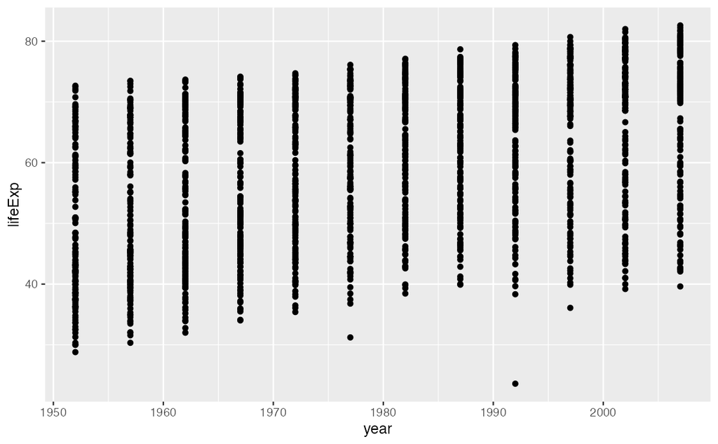

```r
ggplot(df, aes(x = year, y = lifeExp)) + geom_point()
```

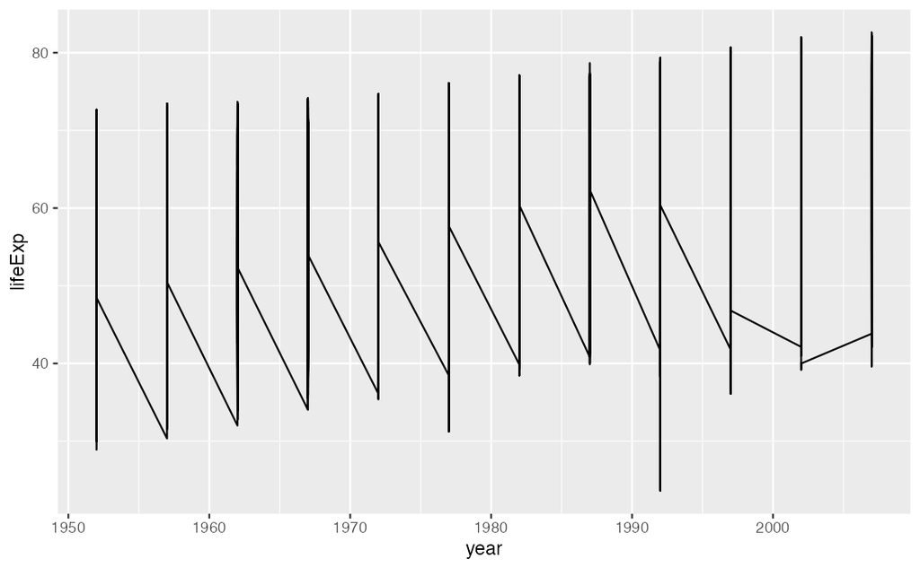

```r
ggplot(df, aes(x = year, y = lifeExp)) + geom_line()
```

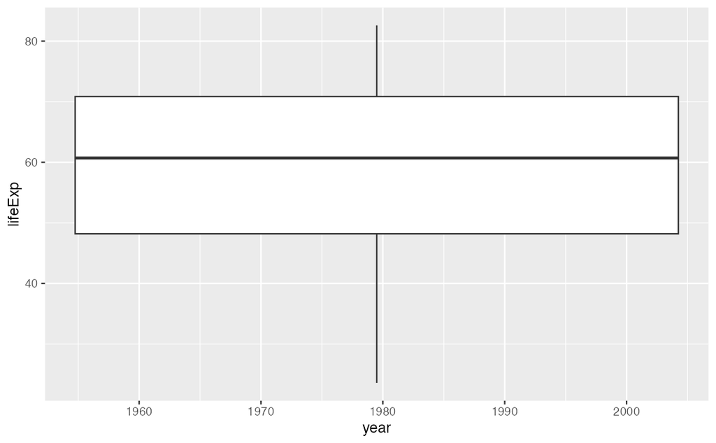

```r
ggplot(df, aes(x = year, y = lifeExp)) + geom_boxplot()
```

```r
typeof(pull(df, year)) # same as typeof(df$year)
```

```
[1] "integer"
```

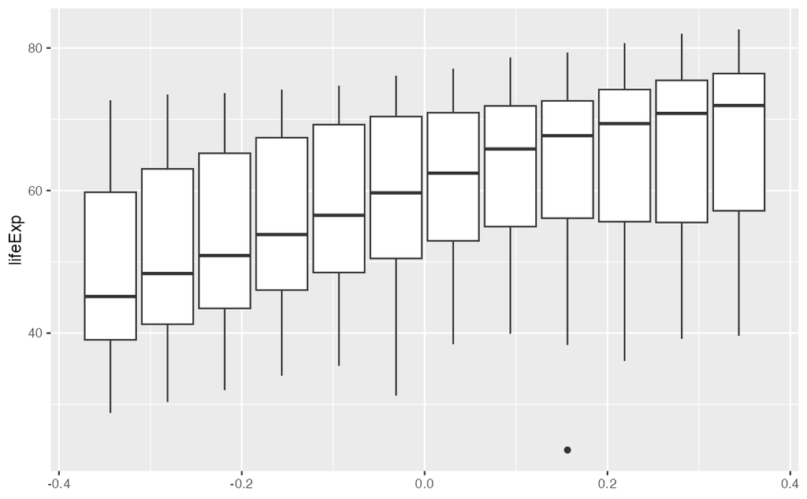

```r
ggplot(df, aes(y = lifeExp, group = year)) + geom_boxplot()
```

##### 2.2.10.4.2 Box Plot

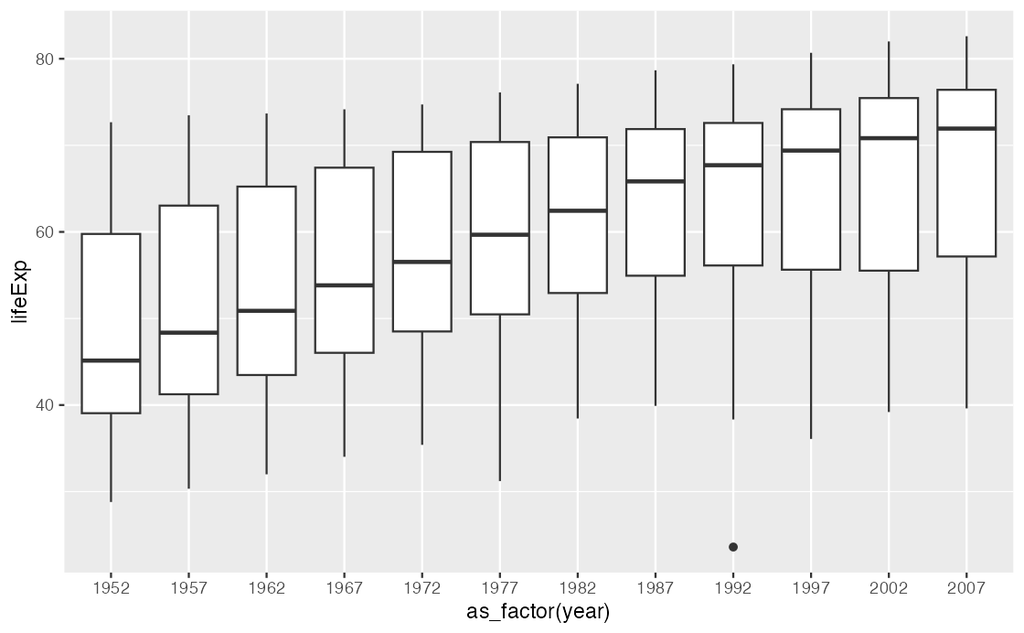

```r
ggplot(df, aes(x = as_factor(year), y = lifeExp)) + geom_boxplot()
```

#### 2.2.10.5 Applications of `dplyr`

##### 2.2.10.5.1 `filter`

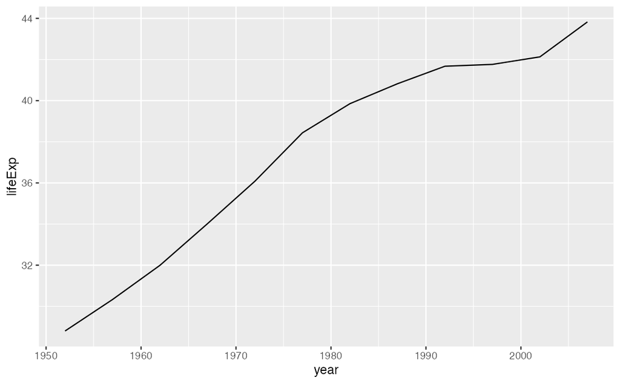

```r
df %>% filter(country == "Afghanistan") %>%
  ggplot(aes(x = year, y = lifeExp)) + geom_line()
```

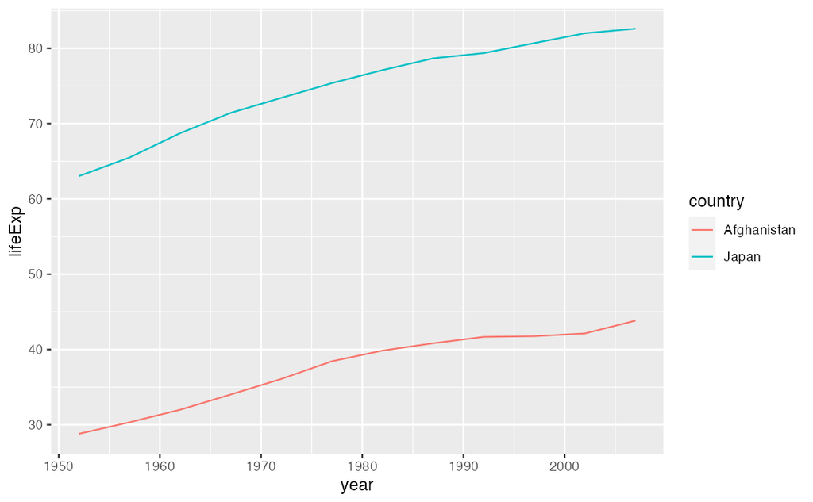

```r
df %>% filter(country %in% c("Afghanistan", "Japan")) %>%
  ggplot(aes(x = year, y = lifeExp, color = country)) + geom_line()
```

```r
df %>% distinct(country) %>% pull()
```

```
  [1] Afghanistan              Albania                  Algeria
  [4] Angola                   Argentina                Australia
  [7] Austria                  Bahrain                  Bangladesh
 [10] Belgium                  Benin                    Bolivia
 [13] Bosnia and Herzegovina   Botswana                 Brazil
 [16] Bulgaria                 Burkina Faso             Burundi
 [19] Cambodia                 Cameroon                 Canada
 [22] Central African Republic Chad                     Chile
 [25] China                    Colombia                 Comoros
 [28] Congo, Dem. Rep.         Congo, Rep.              Costa Rica
 [31] Cote d'Ivoire            Croatia                  Cuba
 [34] Czech Republic           Denmark                  Djibouti
 [37] Dominican Republic       Ecuador                  Egypt
 [40] El Salvador              Equatorial Guinea        Eritrea
 [43] Ethiopia                 Finland                  France
```

[output cut: 34 more lines]

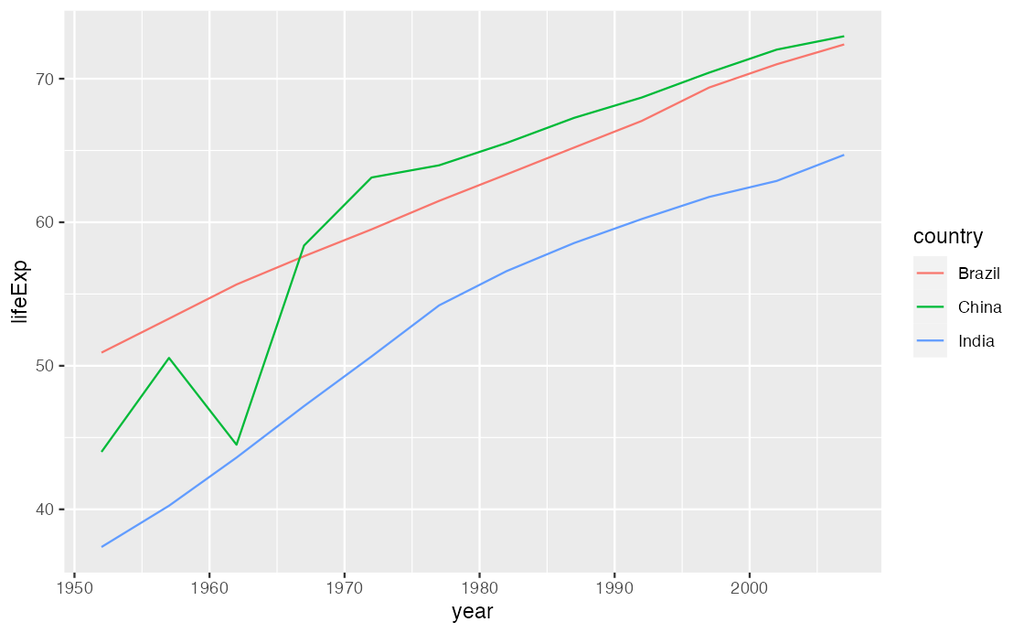

```r
df %>% filter(country %in% c("Brazil", "Russia", "India", "China")) %>%
  ggplot(aes(x = year, y = lifeExp, color = country)) + geom_line()
```

Russian data is missing.

### 2.2.11 Exercises

1. Change `lifeExp` to `pop` and `gdpPercap` and do the same.
2. Choose ASEAN countries and do the similar investigations.
- Brunei, Cambodia, Indonesia, Laos, Malaysia, Myanmar, Philippines, Singapore.
3. Choose several countries by yourself and do the similar investigations.

### 2.2.12 `group_by` and `summarize`

Let us use the variable `continent` and summarize the data.

```r
df_lifeExp <- df %>% group_by(continent, year) %>%
  summarize(mean_lifeExp = mean(lifeExp), median_lifeExp = median(lifeExp), max_lifeExp = max(lifeExp), min_lifeExp = min(lifeExp), .groups = "keep")
```

```r
df_lifeExp
```

| continent | year | mean_lifeExp | median_lifeExp | max_lifeExp | min_lifeExp |
| --- | --- | --- | --- | --- | --- |
| Africa | 1952 | 39.13550 | 38.8330 | 52.724 | 30.000 |
| Africa | 1957 | 41.26635 | 40.5925 | 58.089 | 31.570 |
| Africa | 1962 | 43.31944 | 42.6305 | 60.246 | 32.767 |
| Africa | 1967 | 45.33454 | 44.6985 | 61.557 | 34.113 |
| Africa | 1972 | 47.45094 | 47.0315 | 64.274 | 35.400 |
| Africa | 1977 | 49.58042 | 49.2725 | 67.064 | 36.788 |
| Africa | 1982 | 51.59287 | 50.7560 | 69.885 | 38.445 |
| Africa | 1987 | 53.34479 | 51.6395 | 71.913 | 39.906 |
| Africa | 1992 | 53.62958 | 52.4290 | 73.615 | 23.599 |
| Africa | 1997 | 53.59827 | 52.7590 | 74.772 | 36.087 |

[output cut: 50 more lines]

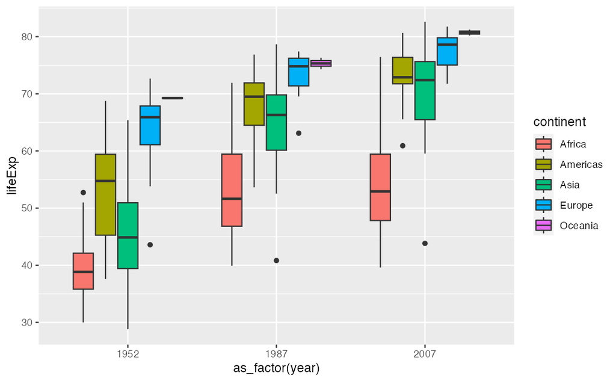

```r
df %>% filter(year %in% c(1952, 1987, 2007)) %>%
  ggplot(aes(x=as_factor(year), y = lifeExp, fill = continent)) +
  geom_boxplot()
```

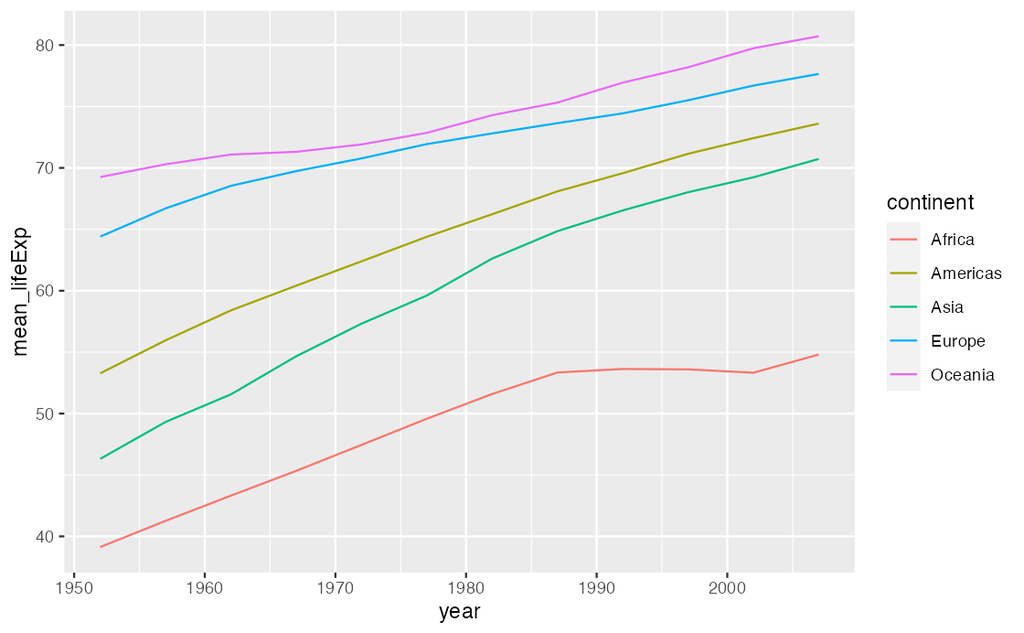

```r
df_lifeExp %>% ggplot(aes(x = year, y = mean_lifeExp, color = continent)) +
  geom_line()
```

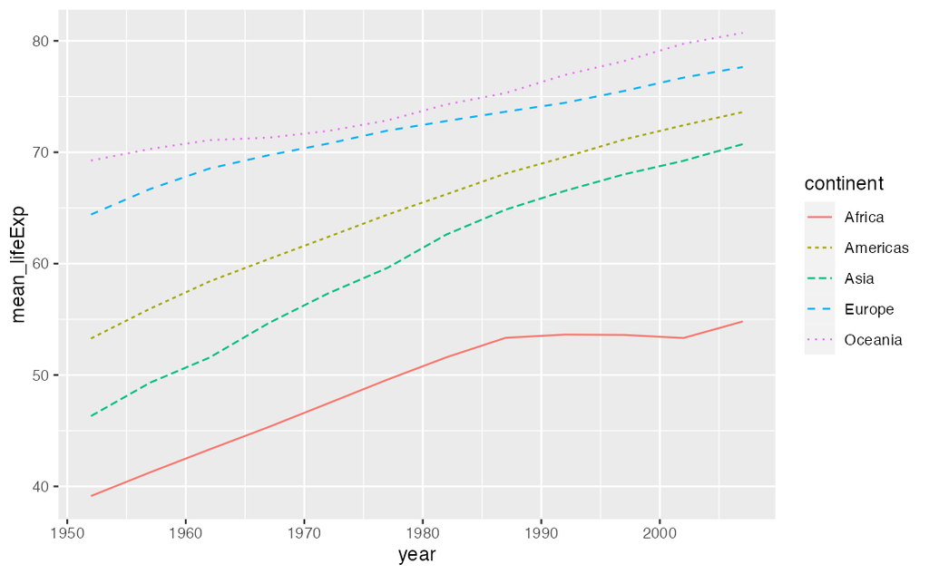

```r
df_lifeExp %>% ggplot(aes(x = year, y = mean_lifeExp, color = continent, linetype = continent)) +
  geom_line()
```

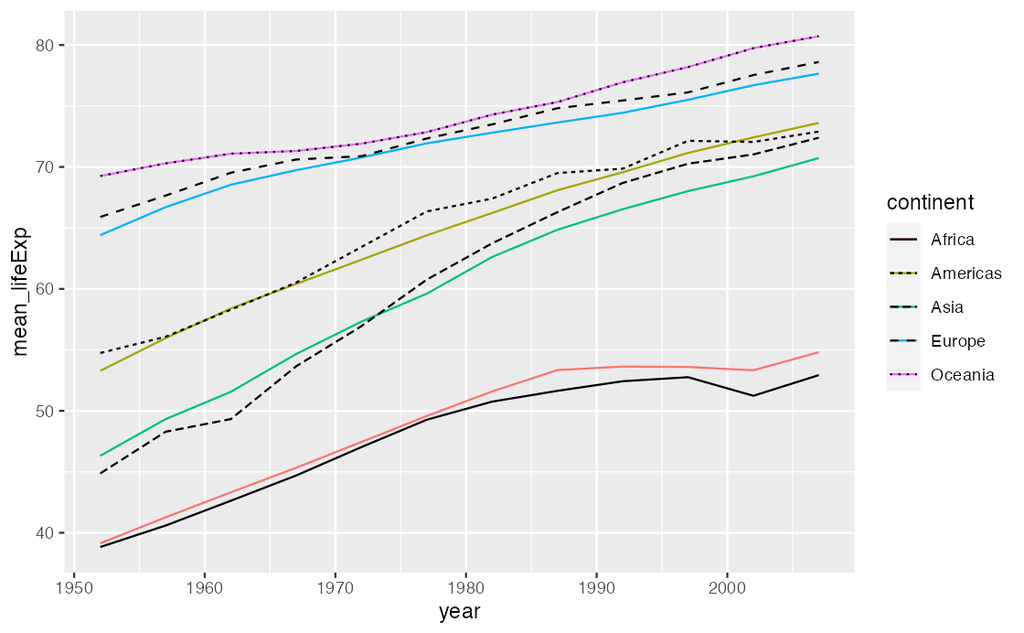

```r
df_lifeExp %>% ggplot() +
  geom_line(aes(x = year, y = mean_lifeExp, color = continent)) +
  geom_line(aes(x = year, y = median_lifeExp, linetype = continent))
```

## 2.3 The Week Two Assignment (in Moodle)

**R Markdown and `dplyr`**

- Create an R Notebook of a Data Analysis containing the following and submit the rendered HTML file (eg. `a2_123456.nb.html`)
  1. create an R Notebook using the R Notebook Template in Moodle, save as `a2_123456.Rmd`,
  2. write your name and ID and the contents,
  3. run each code block,
  4. preview to create `a2_123456.nb.html`,
  5. submit `a2_123456.nb.html` to Moodle.
1. Pick data from the built-in datasets besides `cars`. (`library(help = "datasets")` or go to the site [The R Datasets Package](https://stat.ethz.ch/R-manual/R-devel/library/datasets/html/00Index.html))
   - Information of the data: Name, Description, Usage, Format, Source, References (Hint: ?cars)
   - Use `head()`, `str()`, …, and create at least one chart using `ggplot2` - Code Chunk.
     - Don’t forget to add `library(tidyverse)` in the first code chunk.
   - An observation of the chart - in your own words.
2. Load `gapminder` by `library(gapminder)`.
   - Choose `pop` or `gdpPercap`, or both, one country in the data, a group of countries in the data.
   - Create charts using ggplot2 with geom_line and the variables and countries chosen in 1. (See examples of the charts for `lifeExp`.)
   - Study the data as you like.
   - Observations and difficulties encountered.

**Due:** 2023-01-09 23:59:00. Submit your R Notebook file in Moodle (The Second Assignment). Due on Monday!

### 2.3.1 Original Data? WDI?

```r
gapminder
```

| country | continent | year | lifeExp | pop | gdpPercap |
| --- | --- | --- | --- | --- | --- |
| Afghanistan | Asia | 1952 | 28.80100 | 8425333 | 779.4453 |
| Afghanistan | Asia | 1957 | 30.33200 | 9240934 | 820.8530 |
| Afghanistan | Asia | 1962 | 31.99700 | 10267083 | 853.1007 |
| Afghanistan | Asia | 1967 | 34.02000 | 11537966 | 836.1971 |
| Afghanistan | Asia | 1972 | 36.08800 | 13079460 | 739.9811 |
| Afghanistan | Asia | 1977 | 38.43800 | 14880372 | 786.1134 |
| Afghanistan | Asia | 1982 | 39.85400 | 12881816 | 978.0114 |
| Afghanistan | Asia | 1987 | 40.82200 | 13867957 | 852.3959 |
| Afghanistan | Asia | 1992 | 41.67400 | 16317921 | 649.3414 |
| Afghanistan | Asia | 1997 | 41.76300 | 22227415 | 635.3414 |

[output cut: 990 more lines]

#### 2.3.1.1 WDI

- SP.DYN.LE00.IN: Life expectancy at birth, total (years)
- NY.GDP.PCAP.KD: GDP per capita (constant 2015 US$)
- SP.POP.TOTL: Population, total

```r
df_wdi <- WDI(
  country = "all",
  indicator = c(lifeExp = "SP.DYN.LE00.IN", pop = "SP.POP.TOTL", gdpPercap = "NY.GDP.PCAP.KD")
)
```

```r
df_wdi
```

| country | iso2c | iso3c | year | lifeExp | pop | gdpPercap |
| --- | --- | --- | --- | --- | --- | --- |
| Afghanistan | AF | AFG | 1960 | 32.53500 | 8622466 | NA |
| Afghanistan | AF | AFG | 1961 | 33.06800 | 8790140 | NA |
| Afghanistan | AF | AFG | 1962 | 33.54700 | 8969047 | NA |
| Afghanistan | AF | AFG | 1963 | 34.01600 | 9157465 | NA |
| Afghanistan | AF | AFG | 1964 | 34.49400 | 9355514 | NA |
| Afghanistan | AF | AFG | 1965 | 34.95300 | 9565147 | NA |
| Afghanistan | AF | AFG | 1966 | 35.45300 | 9783147 | NA |
| Afghanistan | AF | AFG | 1967 | 35.92400 | 10010030 | NA |
| Afghanistan | AF | AFG | 1968 | 36.41800 | 10247780 | NA |
| Afghanistan | AF | AFG | 1969 | 36.91000 | 10494489 | NA |

[output cut: 990 more lines]

```r
df_wdi_extra <- WDI(
  country = "all",
  indicator = c(lifeExp = "SP.DYN.LE00.IN", pop = "SP.POP.TOTL", gdpPercap = "NY.GDP.PCAP.KD"),
  extra = TRUE
)
```

```r
df_wdi_extra
```

| country | iso2c | iso3c | year | status | lastupdated | lifeExp | pop | gdpPercap | region | capital | longitude | latitude | income | lending |
| --- | --- | --- | --- | --- | --- | --- | --- | --- | --- | --- | --- | --- | --- | --- |
| Afghanistan | AF | AFG | 1993 |  | 2022-12-22 | 51.46600 | 14003760 | NA | South Asia | Kabul | 69.1761 | 34.5228 | Low income | IDA |
| Afghanistan | AF | AFG | 1997 |  | 2022-12-22 | 53.63400 | 17788819 | NA | South Asia | Kabul | 69.1761 | 34.5228 | Low income | IDA |
| Afghanistan | AF | AFG | 1994 |  | 2022-12-22 | 51.49500 | 15455555 | NA | South Asia | Kabul | 69.1761 | 34.5228 | Low income | IDA |
| Afghanistan | AF | AFG | 1995 |  | 2022-12-22 | 52.54400 | 16418912 | NA | South Asia | Kabul | 69.1761 | 34.5228 | Low income | IDA |
| Afghanistan | AF | AFG | 2001 |  | 2022-12-22 | 55.79800 | 19688632 | NA | South Asia | Kabul | 69.1761 | 34.5228 | Low income | IDA |
| Afghanistan | AF | AFG | 1998 |  | 2022-12-22 | 52.94300 | 18493132 | NA | South Asia | Kabul | 69.1761 | 34.5228 | Low income | IDA |
| Afghanistan | AF | AFG | 1999 |  | 2022-12-22 | 54.84600 | 19262847 | NA | South Asia | Kabul | 69.1761 | 34.5228 | Low income | IDA |
| Afghanistan | AF | AFG | 2007 |  | 2022-12-22 | 59.11100 | 25903301 | 429.4125 | South Asia | Kabul | 69.1761 | 34.5228 | Low income | IDA |
| Afghanistan | AF | AFG | 2008 |  | 2022-12-22 | 59.85200 | 26427199 | 437.4200 | South Asia | Kabul | 69.1761 | 34.5228 | Low income | IDA |
| Afghanistan | AF | AFG | 1980 |  | 2022-12-22 | 39.61800 | 12486631 | NA | South Asia | Kabul | 69.1761 | 34.5228 | Low income | IDA |

[output cut: 990 more lines]

# 3 Exploratory Data Analysis III

## 3.1 Importing Public Data, WDI

### 3.1.1 Reviews and Previews

```r
library(tidyverse)
library(gapminder)
library(maps)
library(WDI)
library(readxl)
library(ggrepel)
```

- We have used `tidyverse` and `gapminder` already.
- If you have not installed `WDI`, install it.
- We will not use `ggrepel` but if you want to use it, install it.
- `maps` and `readxl` are bundled in `tidyverse` but need to be attached by `library`.

#### 3.1.1.1 Gapminder Package Data

```r
df <- gapminder
df
```

| country | continent | year | lifeExp | pop | gdpPercap |
| --- | --- | --- | --- | --- | --- |
| Afghanistan | Asia | 1952 | 28.80100 | 8425333 | 779.4453 |
| Afghanistan | Asia | 1957 | 30.33200 | 9240934 | 820.8530 |
| Afghanistan | Asia | 1962 | 31.99700 | 10267083 | 853.1007 |
| Afghanistan | Asia | 1967 | 34.02000 | 11537966 | 836.1971 |
| Afghanistan | Asia | 1972 | 36.08800 | 13079460 | 739.9811 |
| Afghanistan | Asia | 1977 | 38.43800 | 14880372 | 786.1134 |
| Afghanistan | Asia | 1982 | 39.85400 | 12881816 | 978.0114 |
| Afghanistan | Asia | 1987 | 40.82200 | 13867957 | 852.3959 |
| Afghanistan | Asia | 1992 | 41.67400 | 16317921 | 649.3414 |
| Afghanistan | Asia | 1997 | 41.76300 | 22227415 | 635.3414 |

[output cut: 990 more lines]

#### 3.1.1.2 `gdpPercap` of ASEAN countries

```r
asean <- c("Brunei", "Cambodia", "Laos", "Myanmar",
           "Philippines", "Indonesia", "Malaysia", "Singapore")
df %>% filter(country %in% asean) %>%
  ggplot(aes(x = year, y = gdpPercap, col = country)) + geom_line()
```

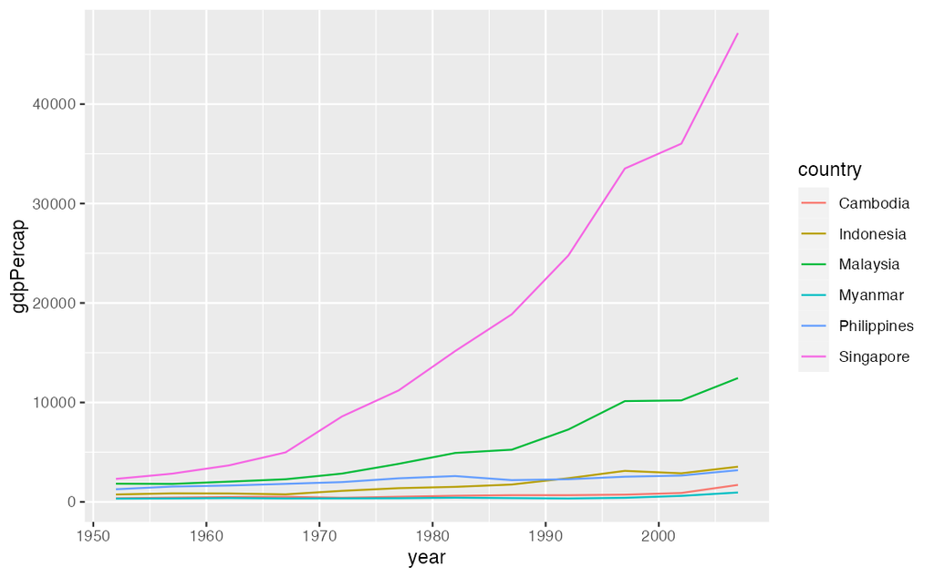

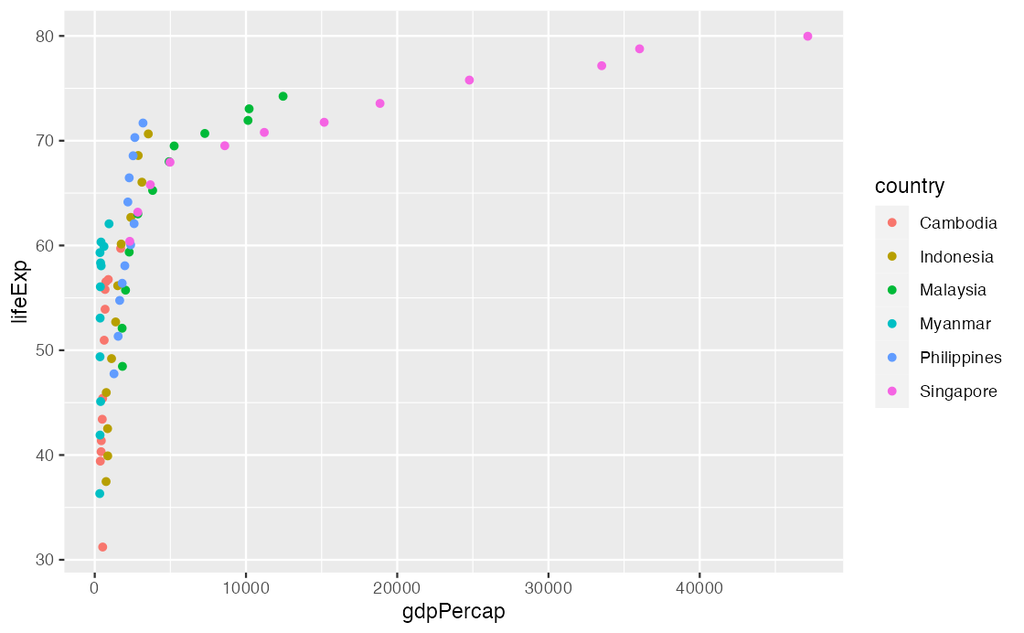

```r
df %>% filter(country %in% asean) %>%
  ggplot(aes(x = gdpPercap, y = lifeExp, col = country)) + geom_point()
```

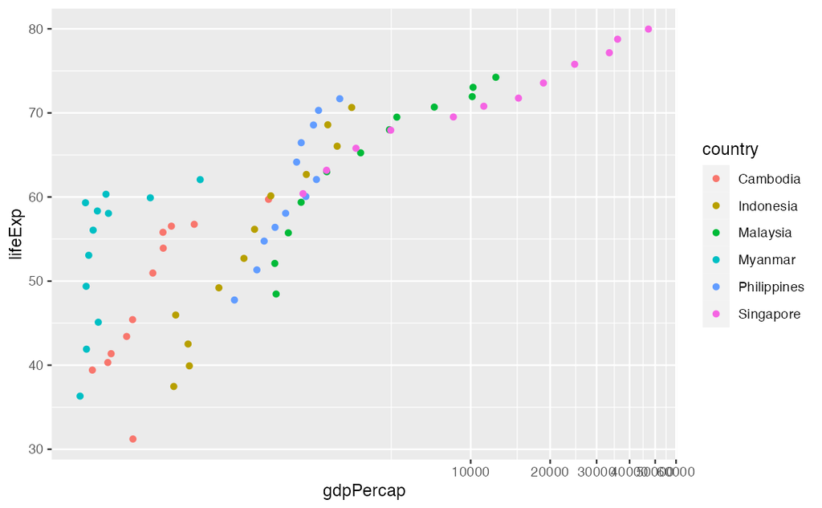

```r
df %>% filter(country %in% asean) %>%
  ggplot(aes(x = gdpPercap, y = lifeExp, col = country)) +
  geom_point() + coord_trans(x = "log10", y = "identity")
```

$\log_{10}{100}$ = 2, $\log_{10}{1000}$ = 3, $\log_{10}{10000}$ = 4

```r
library(ggrepel)
df2007 <- df %>% filter(country %in% asean, year == 2007)
df %>% filter(country %in% asean) %>%
  ggplot(aes(x = gdpPercap, y = lifeExp, col = country))+
  geom_line() + geom_label_repel(data = df2007, aes(label = country)) + geom_point()  +
  coord_trans(x = "log10", y = "identity") +
  theme(axis.text.x = element_text(angle = 90, vjust = 1, hjust=1), legend.position = "none") +
  labs(title = "Life Expectancy vs GDP Per Capita of ASEAN Countries",
       subtitle = "Data: gapminder package", x = "GDP per Capita", y = "Life Expectancy")
```

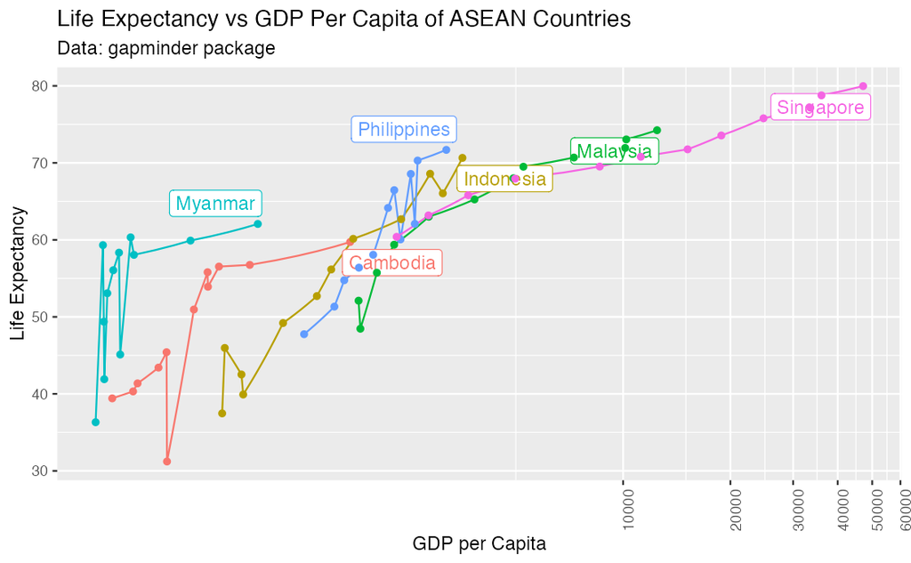

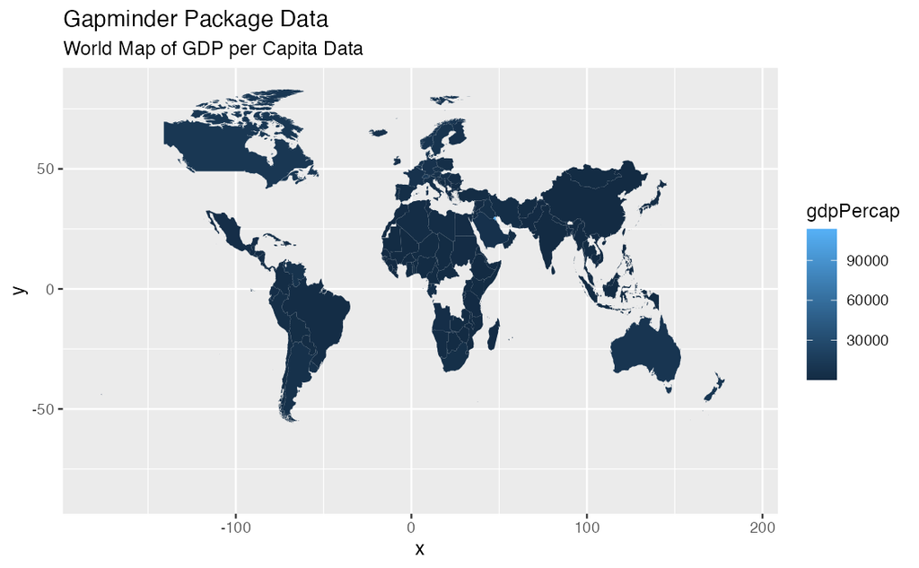

#### 3.1.1.3 World Bank: World Development Indicators (WDI)

- SP.DYN.LE00.IN: Life expectancy at birth, total (years)
- NY.GDP.PCAP.KD: GDP per capita (constant 2015 US$)
- SP.POP.TOTL: Population, total

```r
df_wdi <- WDI(
  country = "all",
  indicator = c(lifeExp = "SP.DYN.LE00.IN", pop = "SP.POP.TOTL", gdpPercap = "NY.GDP.PCAP.KD")
)
```

```r
df_wdi_extra <- WDI(
  country = "all",
  indicator = c(lifeExp = "SP.DYN.LE00.IN", pop = "SP.POP.TOTL", gdpPercap = "NY.GDP.PCAP.KD"),
  extra = TRUE
)
```

### 3.1.2 Exploratory Data Analysis

#### 3.1.2.1 What is EDA (Posit Primers: [Visualise Data](https://posit.cloud/learn/primers/3.1))

EDA is an important part of any data analysis. You can use EDA to make discoveries about the world; or you can use EDA to ensure the quality of your data, asking questions about whether the data meets your standards or not.

### 3.1.3 Open and Public Data, World Bank

#### 3.1.3.1 [Open Government Data Toolkit](http://opendatatoolkit.worldbank.org): [Open Data Defined](http://opendatatoolkit.worldbank.org/en/essentials.html)

The term **Open Data** has a very precise meaning. Data or content is open if anyone is free to use, re-use or redistribute it, subject at most to measures that preserve provenance and openness.

1. The data must be *legally open*, which means they must be placed in the public domain or under liberal terms of use with minimal restrictions.
2. The data must be *technically open*, which means they must be published in electronic formats that are machine readable and non-proprietary, so that anyone can access and use the data using common, freely available software tools. Data must also be publicly available and accessible on a public server, without password or firewall restrictions. To make Open Data easier to find, most organizations create and manage Open Data catalogs.

### 3.1.4 World Bank: WDI - World Development Indicaters

- World Bank: https://www.worldbank.org
- [Who we are](https://www.worldbank.org/en/who-we-are):
  - To end extreme poverty: By reducing the share of the global population that lives in extreme poverty to 3 percent by 2030.
  - To promote shared prosperity: By increasing the incomes of the poorest 40 percent of people in every country.
- World Bank Open Data: https://data.worldbank.org
  - Data Bank, World Development Indicators, etc.
- [World Development Indicators (WDI)](https://datatopics.worldbank.org/world-development-indicators/) : the World Bank’s premier compilation of cross-country comparable data on development; 1400 time series indicators
  - Themes: Poverty and Inequality, People, Environment, Economy, States and Markets, Global Links
  - Open Data & DataBank: Explore data, Query database
  - Bulk Download: Excel, CSV
  - API Documentation

### 3.1.5 R Package WDI

- WDI: World Development Indicators and Other World Bank Data
- Search and download data from over 40 databases hosted by the World Bank, including the World Development Indicators (‘WDI’), International Debt Statistics, Doing Business, Human Capital Index, and Sub-national Poverty indicators.
- Version: 2.7.4
- Materials: [README](https://cran.r-project.org/web/packages/WDI/readme/README.html) - *usage*
  - [NEWS](https://cran.r-project.org/web/packages/WDI/news/news.html) - *version history*
- Published: 2021-04-06
- README: https://cran.r-project.org/web/packages/WDI/readme/README.html
- Reference manual: WDI.pdf

### 3.1.6 Function WDI

- **Usage**

```
WDI(country = "all",
    indicator = "NY.GDP.PCAP.KD",
    start = 1960,
    end = 2020,
    extra = FALSE,
    cache = NULL)
```

- **Arguments** See Help!
  - country: Vector of countries (ISO-2 character codes, e.g. “BR”, “US”, “CA”, or “all”)
  - indicator: If you supply a named vector, the indicators will be automatically renamed: `c('women_private_sector' = 'BI.PWK.PRVS.FE.ZS')`

### 3.1.7 Function WDIsearch

```
WDIsearch(string = "NY.GDP.PCAP.KD",
  field = "indicator", short = FALSE, cache = NULL)
```

```
WDIsearch(string = "gdp",
  field = "name", short = TRUE, cache = NULL)
```

### 3.1.8 Bulk Downloads at WDI site

WDIbulk downloads the zip file of Bulk Downloads in [WDI site](https://datatopics.worldbank.org/world-development-indicators/) , it is a list containing 6 data frames: Data, Country, Series, Country-Series, Series-Time, FootNote.

### 3.1.9 WDIcache

Download an updated list of available WDI indicators from the World Bank website. Returns a list for use in the WDIsearch function.

```r
wdi_cache <- WDIcache()
```

Downloading all series information from the World Bank website can take time. The WDI package ships with a local data object with information on all the series available on 2012-06-18. You can update this database by retrieving a new list using `WDIcache`, and then feeding the resulting object to `WDIsearch` via the cache argument.

```r
wdi_cache
```

### 3.1.10 WDI_data

List of 2 data frames

The first character matrix includes a full list of WDI series. This list is updated semi-regularly. Users can refresh the list manually using the ‘WDIcache()’ function and search in the updated list using the ‘cache’ argument.

### 3.1.11 World Development Indicators - Summary

Find indicators:

1. `WDIsearch(string = "gdp", field = "name", short = FALSE, cache = NULL)`
- `WDIsearch(string = "gdp", field = "name", short = FALSE, cache = wdi_cache)`
- `WDIsearch(string = "NY.GDP.PCAP.KD", field = "indicator", short = FALSE, cache = NULL)`
2. [WDI](https://datatopics.worldbank.org/world-development-indicators/): Data Themes
3. Browse by Indicators: https://data.worldbank.org/indicator
   - Featured Indicators or All Indicators
   - Obtain the indicator from the detail or the URL

#### 3.1.11.1 Example: CO2 emissions (metric tons per capita)

- ID: EN.ATM.CO2E.PC
- URL: https://data.worldbank.org/indicator/EN.ATM.CO2E.PC
- Source: Climate Watch. 2020. GHG Emissions. Washington, DC: World Resources Institute. Available at: climatewatchdata.org/ghg-emissions. See SP.POP.TOTL for the denominator’s source.

```r
co2pcap <- WDI(country = "all", indicator = "EN.ATM.CO2E.PC", start = 1960, end = NULL, extra = TRUE, cache = NULL) #cache = wdi_cache
```

- What is `boxplot`: https://vimeo.com/222358034

```r
co2pcap %>%
  filter(income != "Aggregates", year == 2019) %>%
  ggplot(aes(map_id = country)) +
  geom_map(aes(fill = income), map = world_map) + expand_limits(x = world_map$long, y = world_map$lat) +
  labs(title = "Income Levels in 2019")
```

[output not shown]

```r
map0_url <- "https://icu-hsuzuki.github.io/da4r2022_note/data/world_map0.csv"
world_map0 <- read_csv(map0_url)
```

## 3.2 Data Visualization and `ggplot2’

### 3.2.1 Learning Resouces

- Posit Primers:
  - [Visualize Data](https://posit.cloud/learn/primers/3): Learn how to use ggplot2 to make any type of plot with your data. Then learn the best ways to visualize patterns within values and relationships between variables.
- [r4ds: Data Visualization](https://r4ds.had.co.nz/data-visualisation.html#data-visualisation)

### 3.2.2 Exploratory Data Analysis

#### 3.2.2.1 What is EDA?

EDA is an iterative cycle that helps you understand what your data says. When you do EDA, you:

1. Generate questions about your data
2. Search for answers by visualising, transforming, and/or modeling your data
3. Use what you learn to refine your questions and/or generate new questions

EDA is an important part of any data analysis. You can use EDA to make discoveries about the world; or you can use EDA to ensure the quality of your data, asking questions about whether the data meets your standards or not.

#### 3.2.2.2 Two useful questions

There is no rule about which questions you should ask to guide your research. However, two types of questions will always be useful for making discoveries within your data. You can loosely word these questions as:

1. What type of variation occurs within my variables?
2. What type of covariation occurs between my variables?

The rest of this tutorial will look at these two questions. To make the discussion easier, let’s define some terms…

### 3.2.3 Data Visualization

### 3.2.4 `ggplot2` Basics

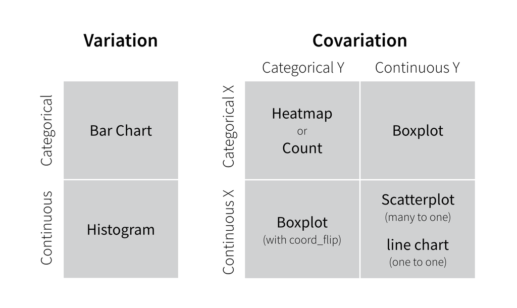

visualization

### 3.2.5 Example: World Inequility Report - WIR2022

- World Inequality Report: https://wir2022.wid.world/
- Executive Summary: https://wir2022.wid.world/executive-summary/
- Methodology: https://wir2022.wid.world/methodology/
- Data URL: https://wir2022.wid.world/www-site/uploads/2022/03/WIR2022TablesFigures-Summary.xlsx

```r
url_summary <- "https://wir2022.wid.world/www-site/uploads/2022/03/WIR2022TablesFigures-Summary.xlsx"
download.file(url = url_summary, destfile = "data/WIR2022s.xlsx")
excel_sheets("data/WIR2022s.xlsx")
```

### 3.2.6 F14: Global carbon inequality, 2019. Group contribution to world emissions (%)

Note that the sheet name of F14 has period at the end.

- `\n` for line break in the title.

#### 3.2.6.1 Categorical vs Continuous Value

#### 3.2.6.2 Memo

- `width = 0.5`: width of bars
- `fill = scales::hue_pal()(1)[1])`: hue scale
  - https://ggplot2.tidyverse.org/reference/scale_hue.html.
- `scale_y_continuous(labels = scales::percent_format(accuracy = 1))`: percent format
  - if accuracy = 0.1, we have 10.0% etc.
- `labs(title = "Figure 14. Global carbon inequality, \n2019 Group contribution to world emissions (%)", x = "", y = "Share of world emissions (%)")`
  - title = ““: `\n` is for line feed
  - x, y: labels of x-axis and y-axis

### 3.2.7 F12: Female share in global labor incomes, 1990-2020

### 3.2.8 F1: Global income and wealth inequality, 2021

### 3.2.9 References of `ggplot2`

- Textbook: [R for Data Science, Data Visualization](https://r4ds.had.co.nz/data-visualisation.html#data-visualisation)

#### 3.2.9.1 RStudio Primers: See References in Moodle at the bottom

**Visualize Data**

- Exploratory Data Analysis
- Bar Charts
- Histograms
- Boxplots and Counts
- Scatterplots
- Line Plots
- Overplotting and Big Data
- Customize Your Plots

## 3.3 The Week Three Assignment (in Moodle)

**WDI and `ggplot2`**

- Create an R Notebook of a Data Analysis containing the following and submit the rendered HTML file (eg. `a3_123456.nb.html` by replacing 123456 with your ID)
  1. create an R Notebook using the R Notebook Template in Moodle, save as `a3_123456.Rmd`,
  2. write your name and ID and the contents,
  3. run each code block,
  4. preview to create `a3_123456.nb.html`,
  5. submit `a3_123456.nb.html` to Moodle.
1. Choose at least one indicator of WDI
   - Information of the data: Name, Indicator, Description, Source, etc.
   - Download the data with `WDI`
   - Explain why you chose the indicator
   - List questions you want to study
2. Explore the data using visualization using `ggplot2`
   - Use a histogram (geom_histogram), boxplot (geom_boxplot), a scatter plot (geom_point), a line plot (geom_line)
   - For at least one chart, add title, and labels of axis, and add an explanation of it
3. Observations and difficulties encountered.

**Due:** 2023-01-16 23:59:00. Submit your R Notebook file in Moodle (The Third Assignment). Due on Monday!

# 4 Exploratory Data Analysis (EDA) IV

## 4.1 Tidy Data

### 4.1.1 Variables, values, and observations: Definitions

- A **variable** is a quantity, quality, or property that you can measure.
- A **value** is the state of a variable when you measure it. The value of a variable may change from measurement to measurement.
- An **observation** or **case** is a set of measurements made under similar conditions (you usually make all of the measurements in an observation at the same time and on the same object). An observation will contain several values, each associated with a different variable. I’ll sometimes refer to an observation as a case or data point.
- **Tabular data** is a table of values, each associated with a variable and an observation. Tabular data is tidy if each value is placed in its own cell, each variable in its own column, and each observation in its own row.
- So far, all of the data that you’ve seen has been tidy. In real-life, most data isn’t tidy, so we’ll come back to these ideas again in Data Wrangling.

### 4.1.2 Tidy Data

> “Data comes in many formats, but R prefers just one: tidy data.” — Garrett Grolemund

Data can come in a variety of formats, but one format is easier to use in R than the others. This format is known as tidy data. A data set is tidy if:

1. Each variable is in its own column
2. Each observation is in its own row
3. Each value is in its own cell (this follows from #1 and #2)

> “Tidy data sets are all alike; but every messy data set is messy in its own way.” — Hadley Wickham

> “all happy families are all alike; each unhappy family is unhappy in its own way” - Tolstoy’s Anna Karenina

### 4.1.3 `tidyr` Basics

## 4.2 Applications `tidyr`

### 4.2.1 WIR2022

`tidyr`, etc.; WDI, WIR, etc

# 5 Exploratory Data Analysis (EDA) V

## 5.1 Modeling

### 5.1.1 Other Examples

## 5.2 Roudups

### 5.2.1 R Markdown Revisited

#### 5.2.1.1 Literate Programming and Reproducible Research

#### 5.2.1.2 Presentation and Paper

1. Data Source
2. Variables
3. Problems
4. Visualization
5. Model
6. Conclusions and Further Research

   WDI, WIR, etc